# Migrating from Toronto to New York (Capstone Project)

1. Introduction
2. Working with Toronto data
3. Toronto Neighborhoods
4. Toronto Venues
5. Toronto top 10 venues for all neighborhoods
6. Toronto Neighborhood Clusters
7. Working with New York data
8. New York Neighborhoods
9. New York Venues
10. New York top 10 venues for all neighborhoods
11. New York Neighborhood Clusters
12. Explore Recommended Cluster
13. Compare top 10 venues of recommended neighborhood with that of originating neighborhood

## Introduction

In this project we will analyze neighborhoods in Toronto and New York. We will draw parallel between the types of neighborhoods in these two cities. We will recommend neighborhoods in New York for someone moving from Toronto.

Before we get the data and start exploring it, let's download all the dependencies that we will need.

```python
import numpy as np # library to handle data in a vectorized manner

import pandas as pd # library for data analsysis
pd.set_option('display.max_columns', None)
pd.set_option('display.max_rows', None)

import json # library to handle JSON files

!conda install -c conda-forge geopy --yes # uncomment this line if you haven't completed the Foursquare API lab
from geopy.geocoders import Nominatim # convert an address into latitude and longitude values

import requests # library to handle requests
from pandas.io.json import json_normalize # tranform JSON file into a pandas dataframe

# Matplotlib and associated plotting modules
import matplotlib.cm as cm
import matplotlib.colors as colors

# import k-means from clustering stage
from sklearn.cluster import KMeans

!conda install -c conda-forge folium=0.5.0 --yes # uncomment this line if you haven't completed the Foursquare API lab
import folium # map rendering library

print('Libraries imported.')
```

[output not shown]

[output cut: 32 more lines]

[output not shown]

## Working with Toronto data

### Scrape data frrm wikipedia page¶

```python
df = pd.read_html('https://en.wikipedia.org/wiki/List_of_postal_codes_of_Canada:_M')[0]
```

### Filter out rows with 'Not assigned' Boroughs¶

```python
df = df[df['Borough'] != 'Not assigned']
```

```python
g = df.groupby("Postcode")
```

```python
#create empty dataframe
new_df = pd.DataFrame(columns=['PostalCode', 'Borough', 'Neighborhood'])

# iterate over group by
for postcode in g.groups:
    l = g.groups[postcode]
    n = ''
    b = ''
    for e in l:
        n +=  (df.loc[e]['Neighbourhood'] + ',')
        b = df.loc[e]['Borough']
    # append to dataframe
    new_df = new_df.append({'PostalCode' : postcode, 'Borough' : b, 'Neighborhood' : n}, ignore_index=True)
```

```python
new_df.head()
```

|  | PostalCode | Borough | Neighborhood |
| --- | --- | --- | --- |
| 0 | M1B | Scarborough | Rouge,Malvern, |
| 1 | M1C | Scarborough | Highland Creek,Rouge Hill,Port Union, |
| 2 | M1E | Scarborough | Guildwood,Morningside,West Hill, |
| 3 | M1G | Scarborough | Woburn, |
| 4 | M1H | Scarborough | Cedarbrae, |

### get geo coordinates for Toronto neighborhoods

```python
geo_coords = pd.read_csv('https://cocl.us/Geospatial_data')
```

```python
geo_coords.rename(columns={'Postal Code' : 'PostalCode'}, inplace = True)
```

### merge above two dataframes

## Toronto Neighborhoods

```python
m = pd.merge(new_df, geo_coords, on='PostalCode')
m.head()
```

|  | PostalCode | Borough | Neighborhood | Latitude | Longitude |
| --- | --- | --- | --- | --- | --- |
| 0 | M1B | Scarborough | Rouge,Malvern, | 43.806686 | -79.194353 |
| 1 | M1C | Scarborough | Highland Creek,Rouge Hill,Port Union, | 43.784535 | -79.160497 |
| 2 | M1E | Scarborough | Guildwood,Morningside,West Hill, | 43.763573 | -79.188711 |
| 3 | M1G | Scarborough | Woburn, | 43.770992 | -79.216917 |
| 4 | M1H | Scarborough | Cedarbrae, | 43.773136 | -79.239476 |

#### Define Foursquare Credentials and Version

```python
CLIENT_ID = '...' # your Foursquare ID
CLIENT_SECRET = '...' # your Foursquare Secret
VERSION = '20200316' # Foursquare API version

print('Your credentails:')
print('CLIENT_ID: ' + CLIENT_ID)
print('CLIENT_SECRET:' + CLIENT_SECRET)
```

```
Your credentails:
CLIENT_ID: ...
CLIENT_SECRET:...
```

```python
LIMIT = 100 # limit of number of venues returned by Foursquare API
radius = 500 # define radius
```

From the Foursquare lab in the previous module, we know that all the information is in the *items* key. Before we proceed, let's borrow the **get_category_type** function from the Foursquare lab.

```python
# function that extracts the category of the venue
def get_category_type(row):
    try:
        categories_list = row['categories']
    except:
        categories_list = row['venue.categories']

    if len(categories_list) == 0:
        return None
    else:
        return categories_list[0]['name']
```

### Function to get nearby venues

```python
def getNearbyVenues(names, latitudes, longitudes, radius=500):

    venues_list=[]
    for name, lat, lng in zip(names, latitudes, longitudes):
        print(name)

        # create the API request URL
        url = 'https://api.foursquare.com/v2/venues/explore?&client_id={}&client_secret={}&v={}&ll={},{}&radius={}&limit={}'.format(
            CLIENT_ID,
            CLIENT_SECRET,
            VERSION,
            lat,
            lng,
            radius,
            LIMIT)

        # make the GET request
        results = requests.get(url).json()["response"]['groups'][0]['items']

        # return only relevant information for each nearby venue
        venues_list.append([(
            name,
            lat,
            lng,
            v['venue']['name'],
            v['venue']['location']['lat'],
            v['venue']['location']['lng'],
            v['venue']['categories'][0]['name']) for v in results])

    nearby_venues = pd.DataFrame([item for venue_list in venues_list for item in venue_list])
    nearby_venues.columns = ['Neighborhood',
                  'Neighborhood Latitude',
                  'Neighborhood Longitude',
                  'Venue',
                  'Venue Latitude',
                  'Venue Longitude',
                  'Venue Category']

    return(nearby_venues)
```

## Toronto Venues

```python
toronto_venues = getNearbyVenues(names=m['Neighborhood'], latitudes=m['Latitude'], longitudes=m['Longitude'])
```

```
Rouge,Malvern,
Highland Creek,Rouge Hill,Port Union,
Guildwood,Morningside,West Hill,
Woburn,
Cedarbrae,
Scarborough Village,
East Birchmount Park,Ionview,Kennedy Park,
Clairlea,Golden Mile,Oakridge,
Cliffcrest,Cliffside,Scarborough Village West,
Birch Cliff,Cliffside West,
Dorset Park,Scarborough Town Centre,Wexford Heights,
Maryvale,Wexford,
Agincourt,
Clarks Corners,Sullivan,Tam O'Shanter,
Agincourt North,L'Amoreaux East,Milliken,Steeles East,
L'Amoreaux West,
Upper Rouge,
Hillcrest Village,
Fairview,Henry Farm,Oriole,
Bayview Village,
Silver Hills,York Mills,
Newtonbrook,Willowdale,
Willowdale South,
York Mills West,
Willowdale West,
Parkwoods,
Don Mills North,
Flemingdon Park,Don Mills South,
Bathurst Manor,Downsview North,Wilson Heights,
Northwood Park,York University,
CFB Toronto,Downsview East,
Downsview West,
Downsview Central,
Downsview Northwest,
Victoria Village,
Woodbine Gardens,Parkview Hill,
Woodbine Heights,
The Beaches,
Leaside,
Thorncliffe Park,
```

[output cut: 48 more lines]

```
Humber Bay Shores,Mimico South,New Toronto,
Alderwood,Long Branch,
The Kingsway,Montgomery Road,Old Mill North,
Humber Bay,King's Mill Park,Kingsway Park South East,Mimico NE,Old Mill South,The Queensway East,Royal York South East,Sunnylea,
Kingsway Park South West,Mimico NW,The Queensway West,Royal York South West,South of Bloor,
Islington Avenue,
Cloverdale,Islington,Martin Grove,Princess Gardens,West Deane Park,
Bloordale Gardens,Eringate,Markland Wood,Old Burnhamthorpe,
Humber Summit,
Emery,Humberlea,
Weston,
Westmount,
Kingsview Village,Martin Grove Gardens,Richview Gardens,St. Phillips,
Albion Gardens,Beaumond Heights,Humbergate,Jamestown,Mount Olive,Silverstone,South Steeles,Thistletown,
Northwest,
```

```python
toronto_venues.head()
```

|  | Neighborhood | Neighborhood Latitude | Neighborhood Longitude | Venue | Venue Latitude | Venue Longitude | Venue Category |
| --- | --- | --- | --- | --- | --- | --- | --- |
| 0 | Rouge,Malvern, | 43.806686 | -79.194353 | Wendy's | 43.807448 | -79.199056 | Fast Food Restaurant |
| 1 | Highland Creek,Rouge Hill,Port Union, | 43.784535 | -79.160497 | Royal Canadian Legion | 43.782533 | -79.163085 | Bar |
| 2 | Guildwood,Morningside,West Hill, | 43.763573 | -79.188711 | G & G Electronics | 43.765309 | -79.191537 | Electronics Store |
| 3 | Guildwood,Morningside,West Hill, | 43.763573 | -79.188711 | Marina Spa | 43.766000 | -79.191000 | Spa |
| 4 | Guildwood,Morningside,West Hill, | 43.763573 | -79.188711 | Big Bite Burrito | 43.766299 | -79.190720 | Mexican Restaurant |

```python
toronto_venues.shape
```

```
(2233, 7)
```

```python
toronto_venues.groupby('Neighborhood').count()
```

| Neighborhood | Neighborhood Latitude | Neighborhood Longitude | Venue | Venue Latitude | Venue Longitude | Venue Category |
| --- | --- | --- | --- | --- | --- | --- |
| Adelaide,King,Richmond, | 100 | 100 | 100 | 100 | 100 | 100 |
| Agincourt North,L'Amoreaux East,Milliken,Steeles East, | 2 | 2 | 2 | 2 | 2 | 2 |
| Agincourt, | 4 | 4 | 4 | 4 | 4 | 4 |
| Albion Gardens,Beaumond Heights,Humbergate,Jamestown,Mount Olive,Silverstone,South Steeles,Thistletown, | 10 | 10 | 10 | 10 | 10 | 10 |
| Alderwood,Long Branch, | 9 | 9 | 9 | 9 | 9 | 9 |
| Bathurst Manor,Downsview North,Wilson Heights, | 21 | 21 | 21 | 21 | 21 | 21 |
| Bayview Village, | 4 | 4 | 4 | 4 | 4 | 4 |
| Bedford Park,Lawrence Manor East, | 24 | 24 | 24 | 24 | 24 | 24 |
| Berczy Park, | 55 | 55 | 55 | 55 | 55 | 55 |
| Birch Cliff,Cliffside West, | 4 | 4 | 4 | 4 | 4 | 4 |
| Bloordale Gardens,Eringate,Markland Wood,Old Burnhamthorpe, | 9 | 9 | 9 | 9 | 9 | 9 |
| Brockton,Exhibition Place,Parkdale Village, | 25 | 25 | 25 | 25 | 25 | 25 |
| Business Reply Mail Processing Centre 969 Eastern, | 17 | 17 | 17 | 17 | 17 | 17 |
| CFB Toronto,Downsview East, | 3 | 3 | 3 | 3 | 3 | 3 |
| CN Tower,Bathurst Quay,Island airport,Harbourfront West,King and Spadina,Railway Lands,South Niagara, | 17 | 17 | 17 | 17 | 17 | 17 |
| Cabbagetown,St. James Town, | 45 | 45 | 45 | 45 | 45 | 45 |
| Caledonia-Fairbanks, | 4 | 4 | 4 | 4 | 4 | 4 |
| Canada Post Gateway Processing Centre, | 12 | 12 | 12 | 12 | 12 | 12 |
| Cedarbrae, | 8 | 8 | 8 | 8 | 8 | 8 |
| Central Bay Street, | 80 | 80 | 80 | 80 | 80 | 80 |
| Chinatown,Grange Park,Kensington Market, | 88 | 88 | 88 | 88 | 88 | 88 |
| Christie, | 18 | 18 | 18 | 18 | 18 | 18 |
| Church and Wellesley, | 86 | 86 | 86 | 86 | 86 | 86 |
| Clairlea,Golden Mile,Oakridge, | 10 | 10 | 10 | 10 | 10 | 10 |
| Clarks Corners,Sullivan,Tam O'Shanter, | 12 | 12 | 12 | 12 | 12 | 12 |
| Cliffcrest,Cliffside,Scarborough Village West, | 3 | 3 | 3 | 3 | 3 | 3 |
| Cloverdale,Islington,Martin Grove,Princess Gardens,West Deane Park, | 1 | 1 | 1 | 1 | 1 | 1 |
| Commerce Court,Victoria Hotel, | 100 | 100 | 100 | 100 | 100 | 100 |
| Davisville North, | 9 | 9 | 9 | 9 | 9 | 9 |
| Davisville, | 35 | 35 | 35 | 35 | 35 | 35 |

[output cut: 70 more lines]

```python
print('There are {} uniques categories.'.format(len(toronto_venues['Venue Category'].unique())))
```

```
There are 265 uniques categories.
```

```python
# one hot encoding
toronto_onehot = pd.get_dummies(toronto_venues[['Venue Category']], prefix="", prefix_sep="")

# add neighborhood column back to dataframe
toronto_onehot['Neighborhood'] = toronto_venues['Neighborhood']

# move neighborhood column to the first column
fixed_columns = [toronto_onehot.columns[-1]] + list(toronto_onehot.columns[:-1])
toronto_onehot = toronto_onehot[fixed_columns]

toronto_onehot.head()
```

|  | Yoga Studio | Accessories Store | Afghan Restaurant | Airport | Airport Food Court | Airport Gate | Airport Lounge | Airport Service | Airport Terminal | American Restaurant | Antique Shop | Aquarium | Art Gallery | Arts & Crafts Store | Asian Restaurant | Athletics & Sports | Auto Workshop | BBQ Joint | Baby Store | Bagel Shop | Bakery | Bank | Bar | Baseball Field | Baseball Stadium | Basketball Court | Basketball Stadium | Beach | Bed & Breakfast | … |
| --- | --- | --- | --- | --- | --- | --- | --- | --- | --- | --- | --- | --- | --- | --- | --- | --- | --- | --- | --- | --- | --- | --- | --- | --- | --- | --- | --- | --- | --- | --- |
| 0 | 0 | 0 | 0 | 0 | 0 | 0 | 0 | 0 | 0 | 0 | 0 | 0 | 0 | 0 | 0 | 0 | 0 | 0 | 0 | 0 | 0 | 0 | 0 | 0 | 0 | 0 | 0 | 0 | 0 | … |
| 1 | 0 | 0 | 0 | 0 | 0 | 0 | 0 | 0 | 0 | 0 | 0 | 0 | 0 | 0 | 0 | 0 | 0 | 0 | 0 | 0 | 0 | 0 | 1 | 0 | 0 | 0 | 0 | 0 | 0 | … |
| 2 | 0 | 0 | 0 | 0 | 0 | 0 | 0 | 0 | 0 | 0 | 0 | 0 | 0 | 0 | 0 | 0 | 0 | 0 | 0 | 0 | 0 | 0 | 0 | 0 | 0 | 0 | 0 | 0 | 0 | … |
| 3 | 0 | 0 | 0 | 0 | 0 | 0 | 0 | 0 | 0 | 0 | 0 | 0 | 0 | 0 | 0 | 0 | 0 | 0 | 0 | 0 | 0 | 0 | 0 | 0 | 0 | 0 | 0 | 0 | 0 | … |
| 4 | 0 | 0 | 0 | 0 | 0 | 0 | 0 | 0 | 0 | 0 | 0 | 0 | 0 | 0 | 0 | 0 | 0 | 0 | 0 | 0 | 0 | 0 | 0 | 0 | 0 | 0 | 0 | 0 | 0 | … |

```python
toronto_grouped = toronto_onehot.groupby('Neighborhood').mean().reset_index()
toronto_grouped
```

|  | Neighborhood | Yoga Studio | Accessories Store | Afghan Restaurant | Airport | Airport Food Court | Airport Gate | Airport Lounge | Airport Service | Airport Terminal | American Restaurant | Antique Shop | Aquarium | Art Gallery | Arts & Crafts Store | Asian Restaurant | Athletics & Sports | Auto Workshop | BBQ Joint | Baby Store | Bagel Shop | Bakery | Bank | Bar | Baseball Field | Baseball Stadium | Basketball Court | Basketball Stadium | Beach | … |
| --- | --- | --- | --- | --- | --- | --- | --- | --- | --- | --- | --- | --- | --- | --- | --- | --- | --- | --- | --- | --- | --- | --- | --- | --- | --- | --- | --- | --- | --- | --- |
| 0 | Adelaide,King,Richmond, | 0.000000 | 0.000000 | 0.000000 | 0.000000 | 0.000000 | 0.000000 | 0.000000 | 0.000000 | 0.000000 | 0.020000 | 0.000000 | 0.00 | 0.000000 | 0.000000 | 0.020000 | 0.000000 | 0.000000 | 0.000000 | 0.000000 | 0.000000 | 0.020000 | 0.000000 | 0.030000 | 0.000000 | 0.00 | 0.000000 | 0.000000 | 0.000000 | … |
| 1 | Agincourt North,L'Amoreaux East,Milliken,Steel... | 0.000000 | 0.000000 | 0.000000 | 0.000000 | 0.000000 | 0.000000 | 0.000000 | 0.000000 | 0.000000 | 0.000000 | 0.000000 | 0.00 | 0.000000 | 0.000000 | 0.000000 | 0.000000 | 0.000000 | 0.000000 | 0.000000 | 0.000000 | 0.000000 | 0.000000 | 0.000000 | 0.000000 | 0.00 | 0.000000 | 0.000000 | 0.000000 | … |
| 2 | Agincourt, | 0.000000 | 0.000000 | 0.000000 | 0.000000 | 0.000000 | 0.000000 | 0.000000 | 0.000000 | 0.000000 | 0.000000 | 0.000000 | 0.00 | 0.000000 | 0.000000 | 0.000000 | 0.000000 | 0.000000 | 0.000000 | 0.000000 | 0.000000 | 0.000000 | 0.000000 | 0.000000 | 0.000000 | 0.00 | 0.000000 | 0.000000 | 0.000000 | … |
| 3 | Albion Gardens,Beaumond Heights,Humbergate,Jam... | 0.000000 | 0.000000 | 0.000000 | 0.000000 | 0.000000 | 0.000000 | 0.000000 | 0.000000 | 0.000000 | 0.000000 | 0.000000 | 0.00 | 0.000000 | 0.000000 | 0.000000 | 0.000000 | 0.000000 | 0.000000 | 0.000000 | 0.000000 | 0.000000 | 0.000000 | 0.000000 | 0.000000 | 0.00 | 0.000000 | 0.000000 | 0.000000 | … |
| 4 | Alderwood,Long Branch, | 0.000000 | 0.000000 | 0.000000 | 0.000000 | 0.000000 | 0.000000 | 0.000000 | 0.000000 | 0.000000 | 0.000000 | 0.000000 | 0.00 | 0.000000 | 0.000000 | 0.000000 | 0.111111 | 0.000000 | 0.000000 | 0.000000 | 0.000000 | 0.000000 | 0.000000 | 0.000000 | 0.000000 | 0.00 | 0.000000 | 0.000000 | 0.000000 | … |
| 5 | Bathurst Manor,Downsview North,Wilson Heights, | 0.000000 | 0.000000 | 0.000000 | 0.000000 | 0.000000 | 0.000000 | 0.000000 | 0.000000 | 0.000000 | 0.000000 | 0.000000 | 0.00 | 0.000000 | 0.000000 | 0.000000 | 0.000000 | 0.000000 | 0.000000 | 0.000000 | 0.000000 | 0.000000 | 0.095238 | 0.000000 | 0.000000 | 0.00 | 0.000000 | 0.000000 | 0.000000 | … |
| 6 | Bayview Village, | 0.000000 | 0.000000 | 0.000000 | 0.000000 | 0.000000 | 0.000000 | 0.000000 | 0.000000 | 0.000000 | 0.000000 | 0.000000 | 0.00 | 0.000000 | 0.000000 | 0.000000 | 0.000000 | 0.000000 | 0.000000 | 0.000000 | 0.000000 | 0.000000 | 0.250000 | 0.000000 | 0.000000 | 0.00 | 0.000000 | 0.000000 | 0.000000 | … |
| 7 | Bedford Park,Lawrence Manor East, | 0.000000 | 0.000000 | 0.000000 | 0.000000 | 0.000000 | 0.000000 | 0.000000 | 0.000000 | 0.000000 | 0.041667 | 0.000000 | 0.00 | 0.000000 | 0.000000 | 0.000000 | 0.000000 | 0.000000 | 0.000000 | 0.000000 | 0.000000 | 0.000000 | 0.000000 | 0.000000 | 0.000000 | 0.00 | 0.000000 | 0.000000 | 0.000000 | … |
| 8 | Berczy Park, | 0.000000 | 0.000000 | 0.000000 | 0.000000 | 0.000000 | 0.000000 | 0.000000 | 0.000000 | 0.000000 | 0.000000 | 0.000000 | 0.00 | 0.018182 | 0.000000 | 0.000000 | 0.000000 | 0.000000 | 0.018182 | 0.000000 | 0.018182 | 0.036364 | 0.000000 | 0.000000 | 0.000000 | 0.00 | 0.000000 | 0.018182 | 0.018182 | … |
| 9 | Birch Cliff,Cliffside West, | 0.000000 | 0.000000 | 0.000000 | 0.000000 | 0.000000 | 0.000000 | 0.000000 | 0.000000 | 0.000000 | 0.000000 | 0.000000 | 0.00 | 0.000000 | 0.000000 | 0.000000 | 0.000000 | 0.000000 | 0.000000 | 0.000000 | 0.000000 | 0.000000 | 0.000000 | 0.000000 | 0.000000 | 0.00 | 0.000000 | 0.000000 | 0.000000 | … |
| 10 | Bloordale Gardens,Eringate,Markland Wood,Old B... | 0.000000 | 0.000000 | 0.000000 | 0.000000 | 0.000000 | 0.000000 | 0.000000 | 0.000000 | 0.000000 | 0.000000 | 0.000000 | 0.00 | 0.000000 | 0.000000 | 0.000000 | 0.000000 | 0.000000 | 0.000000 | 0.000000 | 0.000000 | 0.000000 | 0.000000 | 0.000000 | 0.000000 | 0.00 | 0.000000 | 0.000000 | 0.000000 | … |
| 11 | Brockton,Exhibition Place,Parkdale Village, | 0.040000 | 0.000000 | 0.000000 | 0.000000 | 0.000000 | 0.000000 | 0.000000 | 0.000000 | 0.000000 | 0.000000 | 0.000000 | 0.00 | 0.000000 | 0.000000 | 0.000000 | 0.000000 | 0.000000 | 0.000000 | 0.000000 | 0.000000 | 0.040000 | 0.000000 | 0.040000 | 0.000000 | 0.00 | 0.000000 | 0.000000 | 0.000000 | … |
| 12 | Business Reply Mail Processing Centre 969 East... | 0.058824 | 0.000000 | 0.000000 | 0.000000 | 0.000000 | 0.000000 | 0.000000 | 0.000000 | 0.000000 | 0.000000 | 0.000000 | 0.00 | 0.000000 | 0.000000 | 0.000000 | 0.000000 | 0.058824 | 0.000000 | 0.000000 | 0.000000 | 0.000000 | 0.000000 | 0.000000 | 0.000000 | 0.00 | 0.000000 | 0.000000 | 0.000000 | … |
| 13 | CFB Toronto,Downsview East, | 0.000000 | 0.000000 | 0.000000 | 0.333333 | 0.000000 | 0.000000 | 0.000000 | 0.000000 | 0.000000 | 0.000000 | 0.000000 | 0.00 | 0.000000 | 0.000000 | 0.000000 | 0.000000 | 0.000000 | 0.000000 | 0.000000 | 0.000000 | 0.000000 | 0.000000 | 0.000000 | 0.000000 | 0.00 | 0.000000 | 0.000000 | 0.000000 | … |
| 14 | CN Tower,Bathurst Quay,Island airport,Harbourf... | 0.000000 | 0.000000 | 0.000000 | 0.058824 | 0.058824 | 0.058824 | 0.117647 | 0.176471 | 0.117647 | 0.000000 | 0.000000 | 0.00 | 0.000000 | 0.000000 | 0.000000 | 0.000000 | 0.000000 | 0.000000 | 0.000000 | 0.000000 | 0.000000 | 0.000000 | 0.058824 | 0.000000 | 0.00 | 0.000000 | 0.000000 | 0.000000 | … |
| 15 | Cabbagetown,St. James Town, | 0.000000 | 0.000000 | 0.000000 | 0.000000 | 0.000000 | 0.000000 | 0.000000 | 0.000000 | 0.000000 | 0.000000 | 0.000000 | 0.00 | 0.000000 | 0.000000 | 0.000000 | 0.000000 | 0.000000 | 0.000000 | 0.000000 | 0.000000 | 0.044444 | 0.022222 | 0.000000 | 0.000000 | 0.00 | 0.000000 | 0.000000 | 0.000000 | … |
| 16 | Caledonia-Fairbanks, | 0.000000 | 0.000000 | 0.000000 | 0.000000 | 0.000000 | 0.000000 | 0.000000 | 0.000000 | 0.000000 | 0.000000 | 0.000000 | 0.00 | 0.000000 | 0.000000 | 0.000000 | 0.000000 | 0.000000 | 0.000000 | 0.000000 | 0.000000 | 0.000000 | 0.000000 | 0.000000 | 0.000000 | 0.00 | 0.000000 | 0.000000 | 0.000000 | … |
| 17 | Canada Post Gateway Processing Centre, | 0.000000 | 0.000000 | 0.000000 | 0.000000 | 0.000000 | 0.000000 | 0.000000 | 0.000000 | 0.000000 | 0.083333 | 0.000000 | 0.00 | 0.000000 | 0.000000 | 0.000000 | 0.000000 | 0.000000 | 0.000000 | 0.000000 | 0.000000 | 0.000000 | 0.000000 | 0.000000 | 0.000000 | 0.00 | 0.000000 | 0.000000 | 0.000000 | … |
| 18 | Cedarbrae, | 0.000000 | 0.000000 | 0.000000 | 0.000000 | 0.000000 | 0.000000 | 0.000000 | 0.000000 | 0.000000 | 0.000000 | 0.000000 | 0.00 | 0.000000 | 0.000000 | 0.000000 | 0.125000 | 0.000000 | 0.000000 | 0.000000 | 0.000000 | 0.125000 | 0.125000 | 0.000000 | 0.000000 | 0.00 | 0.000000 | 0.000000 | 0.000000 | … |
| 19 | Central Bay Street, | 0.012500 | 0.000000 | 0.000000 | 0.000000 | 0.000000 | 0.000000 | 0.000000 | 0.000000 | 0.000000 | 0.012500 | 0.000000 | 0.00 | 0.000000 | 0.000000 | 0.000000 | 0.000000 | 0.000000 | 0.000000 | 0.000000 | 0.000000 | 0.000000 | 0.000000 | 0.012500 | 0.000000 | 0.00 | 0.000000 | 0.000000 | 0.000000 | … |
| 20 | Chinatown,Grange Park,Kensington Market, | 0.000000 | 0.000000 | 0.000000 | 0.000000 | 0.000000 | 0.000000 | 0.000000 | 0.000000 | 0.000000 | 0.000000 | 0.000000 | 0.00 | 0.000000 | 0.011364 | 0.000000 | 0.000000 | 0.000000 | 0.000000 | 0.000000 | 0.000000 | 0.045455 | 0.000000 | 0.068182 | 0.000000 | 0.00 | 0.000000 | 0.000000 | 0.000000 | … |
| 21 | Christie, | 0.000000 | 0.000000 | 0.000000 | 0.000000 | 0.000000 | 0.000000 | 0.000000 | 0.000000 | 0.000000 | 0.000000 | 0.000000 | 0.00 | 0.000000 | 0.000000 | 0.000000 | 0.055556 | 0.000000 | 0.000000 | 0.055556 | 0.000000 | 0.000000 | 0.000000 | 0.000000 | 0.000000 | 0.00 | 0.000000 | 0.000000 | 0.000000 | … |
| 22 | Church and Wellesley, | 0.011628 | 0.000000 | 0.011628 | 0.000000 | 0.000000 | 0.000000 | 0.000000 | 0.000000 | 0.000000 | 0.011628 | 0.000000 | 0.00 | 0.000000 | 0.011628 | 0.000000 | 0.000000 | 0.000000 | 0.000000 | 0.000000 | 0.000000 | 0.000000 | 0.000000 | 0.000000 | 0.000000 | 0.00 | 0.000000 | 0.000000 | 0.000000 | … |
| 23 | Clairlea,Golden Mile,Oakridge, | 0.000000 | 0.000000 | 0.000000 | 0.000000 | 0.000000 | 0.000000 | 0.000000 | 0.000000 | 0.000000 | 0.000000 | 0.000000 | 0.00 | 0.000000 | 0.000000 | 0.000000 | 0.000000 | 0.000000 | 0.000000 | 0.000000 | 0.000000 | 0.200000 | 0.000000 | 0.000000 | 0.000000 | 0.00 | 0.000000 | 0.000000 | 0.000000 | … |
| 24 | Clarks Corners,Sullivan,Tam O'Shanter, | 0.000000 | 0.000000 | 0.000000 | 0.000000 | 0.000000 | 0.000000 | 0.000000 | 0.000000 | 0.000000 | 0.000000 | 0.000000 | 0.00 | 0.000000 | 0.000000 | 0.000000 | 0.000000 | 0.000000 | 0.000000 | 0.000000 | 0.000000 | 0.000000 | 0.083333 | 0.000000 | 0.000000 | 0.00 | 0.000000 | 0.000000 | 0.000000 | … |
| 25 | Cliffcrest,Cliffside,Scarborough Village West, | 0.000000 | 0.000000 | 0.000000 | 0.000000 | 0.000000 | 0.000000 | 0.000000 | 0.000000 | 0.000000 | 0.333333 | 0.000000 | 0.00 | 0.000000 | 0.000000 | 0.000000 | 0.000000 | 0.000000 | 0.000000 | 0.000000 | 0.000000 | 0.000000 | 0.000000 | 0.000000 | 0.000000 | 0.00 | 0.000000 | 0.000000 | 0.000000 | … |
| 26 | Cloverdale,Islington,Martin Grove,Princess Gar... | 0.000000 | 0.000000 | 0.000000 | 0.000000 | 0.000000 | 0.000000 | 0.000000 | 0.000000 | 0.000000 | 0.000000 | 0.000000 | 0.00 | 0.000000 | 0.000000 | 0.000000 | 0.000000 | 0.000000 | 0.000000 | 0.000000 | 0.000000 | 0.000000 | 0.000000 | 0.000000 | 0.000000 | 0.00 | 0.000000 | 0.000000 | 0.000000 | … |
| 27 | Commerce Court,Victoria Hotel, | 0.000000 | 0.000000 | 0.000000 | 0.000000 | 0.000000 | 0.000000 | 0.000000 | 0.000000 | 0.000000 | 0.040000 | 0.000000 | 0.00 | 0.010000 | 0.000000 | 0.010000 | 0.000000 | 0.000000 | 0.000000 | 0.000000 | 0.000000 | 0.020000 | 0.000000 | 0.020000 | 0.000000 | 0.00 | 0.000000 | 0.000000 | 0.000000 | … |
| 28 | Davisville North, | 0.000000 | 0.000000 | 0.000000 | 0.000000 | 0.000000 | 0.000000 | 0.000000 | 0.000000 | 0.000000 | 0.000000 | 0.000000 | 0.00 | 0.000000 | 0.000000 | 0.000000 | 0.000000 | 0.000000 | 0.000000 | 0.000000 | 0.000000 | 0.000000 | 0.000000 | 0.000000 | 0.000000 | 0.00 | 0.000000 | 0.000000 | 0.000000 | … |
| 29 | Davisville, | 0.000000 | 0.000000 | 0.000000 | 0.000000 | 0.000000 | 0.000000 | 0.000000 | 0.000000 | 0.000000 | 0.000000 | 0.000000 | 0.00 | 0.000000 | 0.000000 | 0.000000 | 0.000000 | 0.000000 | 0.000000 | 0.000000 | 0.000000 | 0.000000 | 0.000000 | 0.000000 | 0.000000 | 0.00 | 0.000000 | 0.000000 | 0.000000 | … |

[output cut: 70 more lines]

```python
num_top_venues = 5

for hood in toronto_grouped['Neighborhood']:
    print("----"+hood+"----")
    temp = toronto_grouped[toronto_grouped['Neighborhood'] == hood].T.reset_index()
    temp.columns = ['venue','freq']
    temp = temp.iloc[1:]
    temp['freq'] = temp['freq'].astype(float)
    temp = temp.round({'freq': 2})
    print(temp.sort_values('freq', ascending=False).reset_index(drop=True).head(num_top_venues))
    print('\n')
```

```
----Adelaide,King,Richmond,----
             venue  freq
0      Coffee Shop  0.07
1       Restaurant  0.05
2  Thai Restaurant  0.04
3             Café  0.04
4              Bar  0.03


----Agincourt North,L'Amoreaux East,Milliken,Steeles East,----
                       venue  freq
0                       Park   0.5
1                 Playground   0.5
2             Medical Center   0.0
3         Miscellaneous Shop   0.0
4  Middle Eastern Restaurant   0.0


----Agincourt,----
                       venue  freq
0  Latin American Restaurant  0.25
1                     Lounge  0.25
2             Breakfast Spot  0.25
3               Skating Rink  0.25
4                Yoga Studio  0.00


----Albion Gardens,Beaumond Heights,Humbergate,Jamestown,Mount Olive,Silverstone,South Steeles,Thistletown,----
                  venue  freq
0         Grocery Store   0.2
1   Japanese Restaurant   0.1
2              Pharmacy   0.1
3           Pizza Place   0.1
4  Fast Food Restaurant   0.1


----Alderwood,Long Branch,----
                venue  freq
0         Pizza Place  0.22
1  Athletics & Sports  0.11
```

[output cut: 843 more lines]

```
            venue  freq
0            Park  0.12
1        Pharmacy  0.12
2    Skating Rink  0.12
3     Video Store  0.12
4  Cosmetics Shop  0.12


----York Mills West,----
               venue  freq
0               Park  0.25
1               Bank  0.25
2  Electronics Store  0.25
3  Convenience Store  0.25
4        Yoga Studio  0.00
```

### Let's put that into a pandas dataframe

```python
def return_most_common_venues(row, num_top_venues):
    row_categories = row.iloc[1:]
    row_categories_sorted = row_categories.sort_values(ascending=False)

    return row_categories_sorted.index.values[0:num_top_venues]
```

## Toronto top 10 venues for all neighborhoods

```python
num_top_venues = 10

indicators = ['st', 'nd', 'rd']

# create columns according to number of top venues
columns = ['Neighborhood']
for ind in np.arange(num_top_venues):
    try:
        columns.append('{}{} Most Common Venue'.format(ind+1, indicators[ind]))
    except:
        columns.append('{}th Most Common Venue'.format(ind+1))

# create a new dataframe
neighborhoods_venues_sorted = pd.DataFrame(columns=columns)
neighborhoods_venues_sorted['Neighborhood'] = toronto_grouped['Neighborhood']

for ind in np.arange(toronto_grouped.shape[0]):
    neighborhoods_venues_sorted.iloc[ind, 1:] = return_most_common_venues(toronto_grouped.iloc[ind, :], num_top_venues)

neighborhoods_venues_sorted
```

|  | Neighborhood | 1st Most Common Venue | 2nd Most Common Venue | 3rd Most Common Venue | 4th Most Common Venue | 5th Most Common Venue | 6th Most Common Venue | 7th Most Common Venue | 8th Most Common Venue | 9th Most Common Venue | 10th Most Common Venue |
| --- | --- | --- | --- | --- | --- | --- | --- | --- | --- | --- | --- |
| 0 | Adelaide,King,Richmond, | Coffee Shop | Restaurant | Café | Thai Restaurant | Bar | Steakhouse | Sushi Restaurant | Pizza Place | Lounge | Seafood Restaurant |
| 1 | Agincourt North,L'Amoreaux East,Milliken,Steel... | Park | Playground | Distribution Center | Deli / Bodega | Department Store | Dessert Shop | Dim Sum Restaurant | Diner | Discount Store | Dog Run |
| 2 | Agincourt, | Latin American Restaurant | Skating Rink | Breakfast Spot | Lounge | Deli / Bodega | Dumpling Restaurant | Drugstore | Donut Shop | Doner Restaurant | Dog Run |
| 3 | Albion Gardens,Beaumond Heights,Humbergate,Jam... | Grocery Store | Japanese Restaurant | Fast Food Restaurant | Pharmacy | Pizza Place | Sandwich Place | Beer Store | Fried Chicken Joint | Discount Store | Department Store |
| 4 | Alderwood,Long Branch, | Pizza Place | Coffee Shop | Skating Rink | Pub | Gym | Athletics & Sports | Pharmacy | Sandwich Place | Women's Store | Dim Sum Restaurant |
| 5 | Bathurst Manor,Downsview North,Wilson Heights, | Bank | Coffee Shop | Fried Chicken Joint | Supermarket | Sushi Restaurant | Ice Cream Shop | Restaurant | Middle Eastern Restaurant | Deli / Bodega | Pizza Place |
| 6 | Bayview Village, | Chinese Restaurant | Café | Japanese Restaurant | Bank | Women's Store | Dessert Shop | Dim Sum Restaurant | Diner | Discount Store | Distribution Center |
| 7 | Bedford Park,Lawrence Manor East, | Coffee Shop | Sandwich Place | Restaurant | Italian Restaurant | Juice Bar | Fast Food Restaurant | Pub | Butcher | Sushi Restaurant | Indian Restaurant |
| 8 | Berczy Park, | Coffee Shop | Cocktail Bar | Farmers Market | Restaurant | Seafood Restaurant | Café | Cheese Shop | Bakery | Beer Bar | Hotel |
| 9 | Birch Cliff,Cliffside West, | Café | College Stadium | Skating Rink | General Entertainment | Women's Store | Discount Store | Department Store | Dessert Shop | Dim Sum Restaurant | Diner |
| 10 | Bloordale Gardens,Eringate,Markland Wood,Old B... | Café | Shopping Plaza | Coffee Shop | Pet Store | Beer Store | Pizza Place | Liquor Store | Convenience Store | Cosmetics Shop | Women's Store |
| 11 | Brockton,Exhibition Place,Parkdale Village, | Café | Breakfast Spot | Nightclub | Coffee Shop | Yoga Studio | Climbing Gym | Burrito Place | Japanese Restaurant | Italian Restaurant | Intersection |
| 12 | Business Reply Mail Processing Centre 969 East... | Light Rail Station | Yoga Studio | Auto Workshop | Garden Center | Garden | Fast Food Restaurant | Farmers Market | Comic Shop | Pizza Place | Restaurant |
| 13 | CFB Toronto,Downsview East, | Park | Airport | Snack Place | Dumpling Restaurant | Eastern European Restaurant | Drugstore | Donut Shop | Doner Restaurant | Dog Run | Curling Ice |
| 14 | CN Tower,Bathurst Quay,Island airport,Harbourf... | Airport Service | Airport Lounge | Airport Terminal | Coffee Shop | Harbor / Marina | Rental Car Location | Boutique | Boat or Ferry | Airport Gate | Airport Food Court |
| 15 | Cabbagetown,St. James Town, | Coffee Shop | Park | Bakery | Italian Restaurant | Restaurant | Chinese Restaurant | Pizza Place | Pub | Café | Liquor Store |
| 16 | Caledonia-Fairbanks, | Park | Women's Store | Market | Eastern European Restaurant | Dumpling Restaurant | Drugstore | Donut Shop | Doner Restaurant | Dog Run | Dance Studio |
| 17 | Canada Post Gateway Processing Centre, | Hotel | Intersection | Coffee Shop | Sandwich Place | Mediterranean Restaurant | Fried Chicken Joint | Burrito Place | American Restaurant | Gym | Distribution Center |
| 18 | Cedarbrae, | Bank | Fried Chicken Joint | Athletics & Sports | Hakka Restaurant | Caribbean Restaurant | Thai Restaurant | Gas Station | Bakery | Dim Sum Restaurant | Deli / Bodega |
| 19 | Central Bay Street, | Coffee Shop | Italian Restaurant | Juice Bar | Burger Joint | Japanese Restaurant | Café | Ice Cream Shop | Sandwich Place | Bubble Tea Shop | Middle Eastern Restaurant |
| 20 | Chinatown,Grange Park,Kensington Market, | Bar | Vietnamese Restaurant | Café | Coffee Shop | Bakery | Chinese Restaurant | Mexican Restaurant | Vegetarian / Vegan Restaurant | Dumpling Restaurant | Comfort Food Restaurant |
| 21 | Christie, | Grocery Store | Café | Park | Athletics & Sports | Italian Restaurant | Diner | Restaurant | Baby Store | Candy Store | Nightclub |
| 22 | Church and Wellesley, | Coffee Shop | Japanese Restaurant | Sushi Restaurant | Gay Bar | Restaurant | Bubble Tea Shop | Café | Hotel | Men's Store | Burger Joint |
| 23 | Clairlea,Golden Mile,Oakridge, | Bakery | Bus Line | Park | Metro Station | Bus Station | Intersection | Ice Cream Shop | Soccer Field | Garden | Drugstore |
| 24 | Clarks Corners,Sullivan,Tam O'Shanter, | Pizza Place | Noodle House | Pharmacy | Gas Station | Fast Food Restaurant | Italian Restaurant | Bank | Chinese Restaurant | Fried Chicken Joint | Convenience Store |
| 25 | Cliffcrest,Cliffside,Scarborough Village West, | Motel | Movie Theater | American Restaurant | Women's Store | Dance Studio | Department Store | Dessert Shop | Dim Sum Restaurant | Diner | Discount Store |
| 26 | Cloverdale,Islington,Martin Grove,Princess Gar... | Golf Course | Dance Studio | Electronics Store | Eastern European Restaurant | Dumpling Restaurant | Drugstore | Donut Shop | Doner Restaurant | Dog Run | Distribution Center |
| 27 | Commerce Court,Victoria Hotel, | Coffee Shop | Café | Restaurant | Hotel | Gym | American Restaurant | Gastropub | Deli / Bodega | Italian Restaurant | Japanese Restaurant |
| 28 | Davisville North, | Park | Hotel | Food & Drink Shop | Department Store | Sandwich Place | Convenience Store | Dance Studio | Gym | Breakfast Spot | Dog Run |
| 29 | Davisville, | Pizza Place | Sandwich Place | Dessert Shop | Coffee Shop | Italian Restaurant | Gym | Café | Sushi Restaurant | Thai Restaurant | Gourmet Shop |

[output cut: 70 more lines]

```python
toronto_grouped.shape
```

```
(100, 265)
```

## Toronto Neighborhood Clusters

```python
from sklearn.cluster import KMeans
# set number of clusters
kclusters = 5

toronto_grouped_clustering = toronto_grouped.drop('Neighborhood', 1)

# run k-means clustering
kmeans = KMeans(n_clusters=kclusters, random_state=0).fit(toronto_grouped_clustering)

# check cluster labels generated for each row in the dataframe
kmeans.labels_[0:10]
```

```
array([0, 1, 0, 0, 0, 0, 0, 0, 0, 0], dtype=int32)
```

```python
toronto_grouped['Cluster Labels'] = kmeans.labels_
```

```python
m.shape
```

```
(103, 5)
```

```python
m1 = pd.merge(m, toronto_grouped, on='Neighborhood', how='inner')
```

```python
m1.shape
```

```
(100, 270)
```

```python
m1 = m1.join(neighborhoods_venues_sorted.set_index('Neighborhood'), on='Neighborhood')
m1.head()
```

|  | PostalCode | Borough | Neighborhood | Latitude | Longitude | Yoga Studio | Accessories Store | Afghan Restaurant | Airport | Airport Food Court | Airport Gate | Airport Lounge | Airport Service | Airport Terminal | American Restaurant | Antique Shop | Aquarium | Art Gallery | Arts & Crafts Store | Asian Restaurant | Athletics & Sports | Auto Workshop | BBQ Joint | Baby Store | Bagel Shop | Bakery | Bank | Bar | Baseball Field | … |
| --- | --- | --- | --- | --- | --- | --- | --- | --- | --- | --- | --- | --- | --- | --- | --- | --- | --- | --- | --- | --- | --- | --- | --- | --- | --- | --- | --- | --- | --- | --- |
| 0 | M1B | Scarborough | Rouge,Malvern, | 43.806686 | -79.194353 | 0.0 | 0.0 | 0.0 | 0.0 | 0.0 | 0.0 | 0.0 | 0.0 | 0.0 | 0.0 | 0.0 | 0.0 | 0.0 | 0.0 | 0.0 | 0.000 | 0.0 | 0.0 | 0.0 | 0.0 | 0.000 | 0.000 | 0.0 | 0.0 | … |
| 1 | M1C | Scarborough | Highland Creek,Rouge Hill,Port Union, | 43.784535 | -79.160497 | 0.0 | 0.0 | 0.0 | 0.0 | 0.0 | 0.0 | 0.0 | 0.0 | 0.0 | 0.0 | 0.0 | 0.0 | 0.0 | 0.0 | 0.0 | 0.000 | 0.0 | 0.0 | 0.0 | 0.0 | 0.000 | 0.000 | 1.0 | 0.0 | … |
| 2 | M1E | Scarborough | Guildwood,Morningside,West Hill, | 43.763573 | -79.188711 | 0.0 | 0.0 | 0.0 | 0.0 | 0.0 | 0.0 | 0.0 | 0.0 | 0.0 | 0.0 | 0.0 | 0.0 | 0.0 | 0.0 | 0.0 | 0.000 | 0.0 | 0.0 | 0.0 | 0.0 | 0.000 | 0.125 | 0.0 | 0.0 | … |
| 3 | M1G | Scarborough | Woburn, | 43.770992 | -79.216917 | 0.0 | 0.0 | 0.0 | 0.0 | 0.0 | 0.0 | 0.0 | 0.0 | 0.0 | 0.0 | 0.0 | 0.0 | 0.0 | 0.0 | 0.0 | 0.000 | 0.0 | 0.0 | 0.0 | 0.0 | 0.000 | 0.000 | 0.0 | 0.0 | … |
| 4 | M1H | Scarborough | Cedarbrae, | 43.773136 | -79.239476 | 0.0 | 0.0 | 0.0 | 0.0 | 0.0 | 0.0 | 0.0 | 0.0 | 0.0 | 0.0 | 0.0 | 0.0 | 0.0 | 0.0 | 0.0 | 0.125 | 0.0 | 0.0 | 0.0 | 0.0 | 0.125 | 0.125 | 0.0 | 0.0 | … |

```python
# create map
map_clusters = folium.Map(location=[43.653963, -79.387207], zoom_start=11)

# set color scheme for the clusters
x = np.arange(kclusters)
ys = [i+x+(i*x)**2 for i in range(kclusters)]
colors_array = cm.rainbow(np.linspace(0, 1, len(ys)))
rainbow = [colors.rgb2hex(i) for i in colors_array]

# add markers to the map
markers_colors = []
for lat, lon, poi, cluster in zip(m1['Latitude'], m1['Longitude'], m1['Neighborhood'], m1['Cluster Labels']):
    label = folium.Popup(str(poi) + ' Cluster ' + str(cluster), parse_html=True)
    folium.CircleMarker(
        [lat, lon],
        radius=5,
        popup=label,
        color=rainbow[cluster-1],
        fill=True,
        fill_color=rainbow[cluster-1],
        fill_opacity=0.7).add_to(map_clusters)

map_clusters
```

[interactive chart not shown]

### plot number of venues by their category per cluster

```python
g = m1.groupby('Cluster Labels')
```

```python
g.groups
```

```
{0: Int64Index([ 0,  2,  3,  4,  5,  6,  7,  8,  9, 10, 11, 12, 13, 15, 16, 17, 18,
             19, 20, 21, 22, 23, 24, 25, 26, 27, 29, 31, 32, 33, 34, 35, 36, 37,
             39, 40, 41, 43, 44, 45, 47, 49, 50, 51, 52, 53, 54, 55, 56, 57, 58,
             59, 60, 62, 63, 64, 65, 66, 67, 68, 69, 70, 71, 73, 74, 75, 76, 77,
             78, 79, 80, 81, 82, 83, 84, 85, 86, 87, 89, 90, 91, 92, 93, 95, 96,
             97, 98, 99],
            dtype='int64'),
 1: Int64Index([14, 28, 38, 42, 46, 48, 72, 88], dtype='int64'),
 2: Int64Index([61], dtype='int64'),
 3: Int64Index([30, 94], dtype='int64'),
 4: Int64Index([1], dtype='int64')}
```

```python
# create empty dictionary of {'Cluster id' : {'Venue Category' : count}}
d = {}
for name, group in g:
    print (name)
    #for col in ["1st Most Common Venue", "2nd Most Common Venue", "3rd Most Common Venue", "4th Most Common Venue", "5th Most Common Venue",
    #            "6th Most Common Venue", "7th Most Common Venue", "8th Most Common Venue", "9th Most Common Venue", "10th Most Common Venue"]:
    s = group["1st Most Common Venue"].value_counts()
    for items in s.iteritems():
        cd = {}
        if name in d:
            cd = d[name]
        else:
            d[name] = {}

        if items[0] in cd:
            cd[items[0]] = int(cd[items[0]]) + int(items[1])
        else:
            if not cd:
                d[name][items[0]] = items[1]
            else:
                cd[items[0]]= items[1]
        print(items[0], items[1])
```

```
0
Coffee Shop 17
Café 9
Grocery Store 7
Park 6
Pizza Place 5
Clothing Store 3
Mexican Restaurant 2
Indian Restaurant 2
Bank 2
Golf Course 2
Fast Food Restaurant 2
Bar 2
Convenience Store 2
Greek Restaurant 1
Basketball Court 1
Pub 1
Gift Shop 1
Motel 1
Thrift / Vintage Store 1
Cafeteria 1
Bus Stop 1
Mobile Phone Shop 1
Sporting Goods Shop 1
Empanada Restaurant 1
Latin American Restaurant 1
Massage Studio 1
Light Rail Station 1
Pool 1
Bakery 1
Pharmacy 1
Jewelry Store 1
Chinese Restaurant 1
Middle Eastern Restaurant 1
Ramen Restaurant 1
Airport Service 1
Intersection 1
Trail 1
Restaurant 1
Hotel 1
Rental Car Location 1
1
Park 8
2
Garden 1
3
Food Truck 1
Baseball Field 1
4
Bar 1
```

```python
d
```

```
{0: {'Coffee Shop': 17,
  'Café': 9,
  'Grocery Store': 7,
  'Park': 6,
  'Pizza Place': 5,
  'Clothing Store': 3,
  'Mexican Restaurant': 2,
  'Indian Restaurant': 2,
  'Bank': 2,
  'Golf Course': 2,
  'Fast Food Restaurant': 2,
  'Bar': 2,
  'Convenience Store': 2,
  'Greek Restaurant': 1,
  'Basketball Court': 1,
  'Pub': 1,
  'Gift Shop': 1,
  'Motel': 1,
  'Thrift / Vintage Store': 1,
  'Cafeteria': 1,
  'Bus Stop': 1,
  'Mobile Phone Shop': 1,
  'Sporting Goods Shop': 1,
  'Empanada Restaurant': 1,
  'Latin American Restaurant': 1,
  'Massage Studio': 1,
  'Light Rail Station': 1,
  'Pool': 1,
  'Bakery': 1,
  'Pharmacy': 1,
  'Jewelry Store': 1,
  'Chinese Restaurant': 1,
  'Middle Eastern Restaurant': 1,
  'Ramen Restaurant': 1,
  'Airport Service': 1,
  'Intersection': 1,
  'Trail': 1,
  'Restaurant': 1,
  'Hotel': 1,
  'Rental Car Location': 1},
 1: {'Park': 8},
 2: {'Garden': 1},
 3: {'Food Truck': 1, 'Baseball Field': 1},
 4: {'Bar': 1}}
```

```python
df = pd.DataFrame(columns=['ClusterId', 'Venue Category', 'Count'])

for cluster in d:
    c = d[cluster]
    for vc in c:
        df = df.append({'ClusterId' : cluster, 'Venue Category' : vc, 'Count' : c[vc]}, ignore_index = True)

df.head()
```

|  | ClusterId | Venue Category | Count |
| --- | --- | --- | --- |
| 0 | 0 | Coffee Shop | 17 |
| 1 | 0 | Café | 9 |
| 2 | 0 | Grocery Store | 7 |
| 3 | 0 | Park | 6 |
| 4 | 0 | Pizza Place | 5 |

```
ClusterId
0    AxesSubplot(0.125,0.125;0.775x0.755)
1    AxesSubplot(0.125,0.125;0.775x0.755)
2    AxesSubplot(0.125,0.125;0.775x0.755)
3    AxesSubplot(0.125,0.125;0.775x0.755)
4    AxesSubplot(0.125,0.125;0.775x0.755)
dtype: object
```

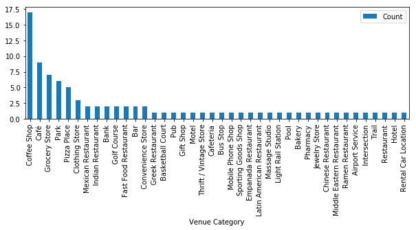

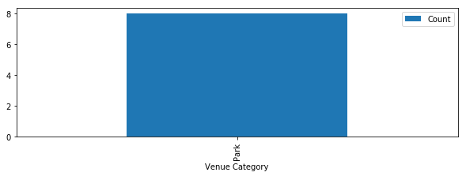

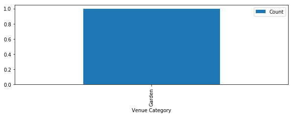

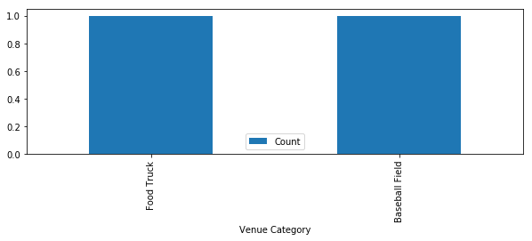

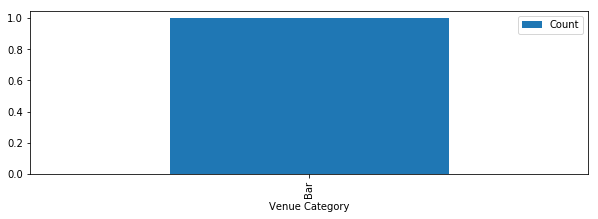

```python
df.groupby('ClusterId').plot(kind = 'bar', x = 'Venue Category', y = 'Count', figsize=(10, 3))
```

```python
m1[m1['PostalCode'] == 'M6E']
```

|  | PostalCode | Borough | Neighborhood | Latitude | Longitude | Yoga Studio | Accessories Store | Afghan Restaurant | Airport | Airport Food Court | Airport Gate | Airport Lounge | Airport Service | Airport Terminal | American Restaurant | Antique Shop | Aquarium | Art Gallery | Arts & Crafts Store | Asian Restaurant | Athletics & Sports | Auto Workshop | BBQ Joint | Baby Store | Bagel Shop | Bakery | Bank | Bar | Baseball Field | … |
| --- | --- | --- | --- | --- | --- | --- | --- | --- | --- | --- | --- | --- | --- | --- | --- | --- | --- | --- | --- | --- | --- | --- | --- | --- | --- | --- | --- | --- | --- | --- |
| 72 | M6E | York | Caledonia-Fairbanks, | 43.689026 | -79.453512 | 0.0 | 0.0 | 0.0 | 0.0 | 0.0 | 0.0 | 0.0 | 0.0 | 0.0 | 0.0 | 0.0 | 0.0 | 0.0 | 0.0 | 0.0 | 0.0 | 0.0 | 0.0 | 0.0 | 0.0 | 0.0 | 0.0 | 0.0 | 0.0 | … |

```python
m1[m1['Cluster Labels'] == 1]
```

|  | PostalCode | Borough | Neighborhood | Latitude | Longitude | Yoga Studio | Accessories Store | Afghan Restaurant | Airport | Airport Food Court | Airport Gate | Airport Lounge | Airport Service | Airport Terminal | American Restaurant | Antique Shop | Aquarium | Art Gallery | Arts & Crafts Store | Asian Restaurant | Athletics & Sports | Auto Workshop | BBQ Joint | Baby Store | Bagel Shop | Bakery | Bank | Bar | Baseball Field | … |
| --- | --- | --- | --- | --- | --- | --- | --- | --- | --- | --- | --- | --- | --- | --- | --- | --- | --- | --- | --- | --- | --- | --- | --- | --- | --- | --- | --- | --- | --- | --- |
| 14 | M1V | Scarborough | Agincourt North,L'Amoreaux East,Milliken,Steel... | 43.815252 | -79.284577 | 0.0 | 0.0 | 0.0 | 0.000000 | 0.0 | 0.0 | 0.0 | 0.0 | 0.0 | 0.0 | 0.0 | 0.0 | 0.0 | 0.0 | 0.0 | 0.0 | 0.0 | 0.0 | 0.0 | 0.0 | 0.0 | 0.0 | 0.0 | 0.0 | … |
| 28 | M3K | North York | CFB Toronto,Downsview East, | 43.737473 | -79.464763 | 0.0 | 0.0 | 0.0 | 0.333333 | 0.0 | 0.0 | 0.0 | 0.0 | 0.0 | 0.0 | 0.0 | 0.0 | 0.0 | 0.0 | 0.0 | 0.0 | 0.0 | 0.0 | 0.0 | 0.0 | 0.0 | 0.0 | 0.0 | 0.0 | … |
| 38 | M4J | East York | East Toronto, | 43.685347 | -79.338106 | 0.0 | 0.0 | 0.0 | 0.000000 | 0.0 | 0.0 | 0.0 | 0.0 | 0.0 | 0.0 | 0.0 | 0.0 | 0.0 | 0.0 | 0.0 | 0.0 | 0.0 | 0.0 | 0.0 | 0.0 | 0.0 | 0.0 | 0.0 | 0.0 | … |
| 42 | M4N | Central Toronto | Lawrence Park, | 43.728020 | -79.388790 | 0.0 | 0.0 | 0.0 | 0.000000 | 0.0 | 0.0 | 0.0 | 0.0 | 0.0 | 0.0 | 0.0 | 0.0 | 0.0 | 0.0 | 0.0 | 0.0 | 0.0 | 0.0 | 0.0 | 0.0 | 0.0 | 0.0 | 0.0 | 0.0 | … |
| 46 | M4T | Central Toronto | Moore Park,Summerhill East, | 43.689574 | -79.383160 | 0.0 | 0.0 | 0.0 | 0.000000 | 0.0 | 0.0 | 0.0 | 0.0 | 0.0 | 0.0 | 0.0 | 0.0 | 0.0 | 0.0 | 0.0 | 0.0 | 0.0 | 0.0 | 0.0 | 0.0 | 0.0 | 0.0 | 0.0 | 0.0 | … |
| 48 | M4W | Downtown Toronto | Rosedale, | 43.679563 | -79.377529 | 0.0 | 0.0 | 0.0 | 0.000000 | 0.0 | 0.0 | 0.0 | 0.0 | 0.0 | 0.0 | 0.0 | 0.0 | 0.0 | 0.0 | 0.0 | 0.0 | 0.0 | 0.0 | 0.0 | 0.0 | 0.0 | 0.0 | 0.0 | 0.0 | … |
| 72 | M6E | York | Caledonia-Fairbanks, | 43.689026 | -79.453512 | 0.0 | 0.0 | 0.0 | 0.000000 | 0.0 | 0.0 | 0.0 | 0.0 | 0.0 | 0.0 | 0.0 | 0.0 | 0.0 | 0.0 | 0.0 | 0.0 | 0.0 | 0.0 | 0.0 | 0.0 | 0.0 | 0.0 | 0.0 | 0.0 | … |
| 88 | M8X | Etobicoke | The Kingsway,Montgomery Road,Old Mill North, | 43.653654 | -79.506944 | 0.0 | 0.0 | 0.0 | 0.000000 | 0.0 | 0.0 | 0.0 | 0.0 | 0.0 | 0.0 | 0.0 | 0.0 | 0.0 | 0.0 | 0.0 | 0.0 | 0.0 | 0.0 | 0.0 | 0.0 | 0.0 | 0.0 | 0.0 | 0.0 | … |

## Working with New York data

Neighborhood has a total of 5 boroughs and 306 neighborhoods. In order to segement the neighborhoods and explore them, we will essentially need a dataset that contains the 5 boroughs and the neighborhoods that exist in each borough as well as the the latitude and logitude coordinates of each neighborhood.

Luckily, this dataset exists for free on the web. Feel free to try to find this dataset on your own, but here is the link to the dataset: https://geo.nyu.edu/catalog/nyu_2451_34572

For your convenience, I downloaded the files and placed it on the server, so you can simply run a `wget` command and access the data. So let's go ahead and do that.

```python
!wget -q -O 'newyork_data.json' https://ibm.box.com/shared/static/fbpwbovar7lf8p5sgddm06cgipa2rxpe.json
print('Data downloaded!')
```

```
Data downloaded!
```

#### Load and explore the data

Next, let's load the data.

```python
with open('newyork_data.json') as json_data:
    newyork_data = json.load(json_data)
```

Let's take a quick look at the data.

```python
newyork_data
```

[output not shown]

[output cut: 4848 more lines]

[output not shown]

Notice how all the relevant data is in the *features* key, which is basically a list of the neighborhoods. So, let's define a new variable that includes this data.

```python
neighborhoods_data = newyork_data['features']
```

Let's take a look at the first item in this list.

```python
neighborhoods_data[0]
```

```
{'type': 'Feature',
 'id': 'nyu_2451_34572.1',
 'geometry': {'type': 'Point',
  'coordinates': [-73.84720052054902, 40.89470517661]},
 'geometry_name': 'geom',
 'properties': {'name': 'Wakefield',
  'stacked': 1,
  'annoline1': 'Wakefield',
  'annoline2': None,
  'annoline3': None,
  'annoangle': 0.0,
  'borough': 'Bronx',
  'bbox': [-73.84720052054902,
   40.89470517661,
   -73.84720052054902,
   40.89470517661]}}
```

## New York Neighborhoods

#### Tranform the data into a *pandas* dataframe

The next task is essentially transforming this data of nested Python dictionaries into a *pandas* dataframe. So let's start by creating an empty dataframe.

```python
# define the dataframe columns
column_names = ['Borough', 'Neighborhood', 'Latitude', 'Longitude']

# instantiate the dataframe
neighborhoods = pd.DataFrame(columns=column_names)
```

Take a look at the empty dataframe to confirm that the columns are as intended.

```python
neighborhoods
```

|  | Borough | Neighborhood | Latitude | Longitude |
| --- | --- | --- | --- | --- |

Then let's loop through the data and fill the dataframe one row at a time.

```python
for data in neighborhoods_data:
    borough = neighborhood_name = data['properties']['borough']
    neighborhood_name = data['properties']['name']

    neighborhood_latlon = data['geometry']['coordinates']
    neighborhood_lat = neighborhood_latlon[1]
    neighborhood_lon = neighborhood_latlon[0]

    neighborhoods = neighborhoods.append({'Borough': borough,
                                          'Neighborhood': neighborhood_name,
                                          'Latitude': neighborhood_lat,
                                          'Longitude': neighborhood_lon}, ignore_index=True)
```

Quickly examine the resulting dataframe.

```python
neighborhoods.head()
```

|  | Borough | Neighborhood | Latitude | Longitude |
| --- | --- | --- | --- | --- |
| 0 | Bronx | Wakefield | 40.894705 | -73.847201 |
| 1 | Bronx | Co-op City | 40.874294 | -73.829939 |
| 2 | Bronx | Eastchester | 40.887556 | -73.827806 |
| 3 | Bronx | Fieldston | 40.895437 | -73.905643 |
| 4 | Bronx | Riverdale | 40.890834 | -73.912585 |

And make sure that the dataset has all 5 boroughs and 306 neighborhoods.

```python
print('The dataframe has {} boroughs and {} neighborhoods.'.format(
        len(neighborhoods['Borough'].unique()),
        neighborhoods.shape[0]
    )
)
```

```
The dataframe has 5 boroughs and 306 neighborhoods.
```

#### Use geopy library to get the latitude and longitude values of New York City.

```python
address = 'New York City, NY'

geolocator = Nominatim()
location = geolocator.geocode(address)
latitude = location.latitude
longitude = location.longitude
print('The geograpical coordinate of New York City are {}, {}.'.format(latitude, longitude))
```

```
The geograpical coordinate of New York City are 40.7127281, -74.0060152.
```

#### Create a map of New York with neighborhoods superimposed on top.

```python
# create map of New York using latitude and longitude values
map_newyork = folium.Map(location=[latitude, longitude], zoom_start=10)

# add markers to map
for lat, lng, borough, neighborhood in zip(neighborhoods['Latitude'], neighborhoods['Longitude'], neighborhoods['Borough'], neighborhoods['Neighborhood']):
    label = '{}, {}'.format(neighborhood, borough)
    label = folium.Popup(label, parse_html=True)
    folium.CircleMarker(
        [lat, lng],
        radius=5,
        popup=label,
        color='blue',
        fill=True,
        fill_color='#3186cc',
        fill_opacity=0.7,
        parse_html=False).add_to(map_newyork)

map_newyork
```

[interactive chart not shown]

**Folium** is a great visualization library. Feel free to zoom into the above map, and click on each circle mark to reveal the name of the neighborhood and its respective borough.

However, for illustration purposes, let's simplify the above map and segment and cluster only the neighborhoods in Manhattan. So let's slice the original dataframe and create a new dataframe of the Manhattan data.

```python
manhattan_data = neighborhoods[neighborhoods['Borough'] == 'Manhattan'].reset_index(drop=True)
manhattan_data.head()
```

|  | Borough | Neighborhood | Latitude | Longitude |
| --- | --- | --- | --- | --- |
| 0 | Manhattan | Marble Hill | 40.876551 | -73.910660 |
| 1 | Manhattan | Chinatown | 40.715618 | -73.994279 |
| 2 | Manhattan | Washington Heights | 40.851903 | -73.936900 |
| 3 | Manhattan | Inwood | 40.867684 | -73.921210 |
| 4 | Manhattan | Hamilton Heights | 40.823604 | -73.949688 |

Let's get the geographical coordinates of Manhattan.

```python
address = 'Manhattan, NY'

geolocator = Nominatim()
location = geolocator.geocode(address)
latitude = location.latitude
longitude = location.longitude
print('The geograpical coordinate of Manhattan are {}, {}.'.format(latitude, longitude))
```

```
The geograpical coordinate of Manhattan are 40.7896239, -73.9598939.
```

As we did with all of New York City, let's visualizat Manhattan the neighborhoods in it.

```python
# create map of Manhattan using latitude and longitude values
map_manhattan = folium.Map(location=[latitude, longitude], zoom_start=11)

# add markers to map
for lat, lng, label in zip(manhattan_data['Latitude'], manhattan_data['Longitude'], manhattan_data['Neighborhood']):
    label = folium.Popup(label, parse_html=True)
    folium.CircleMarker(
        [lat, lng],
        radius=5,
        popup=label,
        color='blue',
        fill=True,
        fill_color='#3186cc',
        fill_opacity=0.7,
        parse_html=False).add_to(map_manhattan)

map_manhattan
```

[interactive chart not shown]

Next, we are going to start utilizing the Foursquare API to explore the neighborhoods and segment them.

#### Let's explore the first neighborhood in our dataframe.

Get the neighborhood's name.

```python
manhattan_data.loc[0, 'Neighborhood']
```

```
'Marble Hill'
```

Get the neighborhood's latitude and longitude values.

```python
neighborhood_latitude = manhattan_data.loc[0, 'Latitude'] # neighborhood latitude value
neighborhood_longitude = manhattan_data.loc[0, 'Longitude'] # neighborhood longitude value

neighborhood_name = manhattan_data.loc[0, 'Neighborhood'] # neighborhood name

print('Latitude and longitude values of {} are {}, {}.'.format(neighborhood_name,
                                                               neighborhood_latitude,
                                                               neighborhood_longitude))
```

```
Latitude and longitude values of Marble Hill are 40.87655077879964, -73.91065965862981.
```

## New York Venues

#### Now, let's get the top 100 venues that are in Marble Hill within a radius of 500 meters.

First, let's create the GET request URL. Name your URL **url**.

```python
url = 'https://api.foursquare.com/v2/venues/explore?&client_id={}&client_secret={}&v={}&ll={},{}&radius={}&limit={}'.format(
    CLIENT_ID,
    CLIENT_SECRET,
    VERSION,
    neighborhood_latitude,
    neighborhood_longitude,
    radius,
    LIMIT)
url
```

```
'https://api.foursquare.com/v2/venues/explore?&client_id=HK3ZHLLVPB3RNF33MU3N120GPO5LEU3OVHEMJBCFMDGXCK5L&client_secret=VEGOVTKT2AKY1OVUCNYHZMFQA0P2EQ2H2YI0IDT1CEJYGM0F&v=20200316&ll=40.87655077879964,-73.91065965862981&radius=500&limit=100'
```

Send the GET request and examine the resutls

```python
results = requests.get(url).json()["response"]
results
```

[output not shown]

[output cut: 746 more lines]

[output not shown]

Now we are ready to clean the json and structure it into a *pandas* dataframe.

```python
venues = results['groups'][0]['items']

nearby_venues = json_normalize(venues) # flatten JSON

# filter columns
filtered_columns = ['venue.name', 'venue.categories', 'venue.location.lat', 'venue.location.lng']
nearby_venues =nearby_venues.loc[:, filtered_columns]

# filter the category for each row
nearby_venues['venue.categories'] = nearby_venues.apply(get_category_type, axis=1)

# clean columns
nearby_venues.columns = [col.split(".")[-1] for col in nearby_venues.columns]

nearby_venues.head()
```

|  | name | categories | lat | lng |
| --- | --- | --- | --- | --- |
| 0 | Arturo's | Pizza Place | 40.874412 | -73.910271 |
| 1 | Bikram Yoga | Yoga Studio | 40.876844 | -73.906204 |
| 2 | Tibbett Diner | Diner | 40.880404 | -73.908937 |
| 3 | Dunkin' | Donut Shop | 40.877136 | -73.906666 |
| 4 | Starbucks | Coffee Shop | 40.877531 | -73.905582 |

And how many venues were returned by Foursquare?

```python
print('{} venues were returned by Foursquare.'.format(nearby_venues.shape[0]))
```

```
25 venues were returned by Foursquare.
```

#### Now write the code to run the above function on each neighborhood and create a new dataframe called *manhattan_venues*.

```python
# type your answer here

manhattan_venues = getNearbyVenues(names=manhattan_data['Neighborhood'],
                                   latitudes=manhattan_data['Latitude'],
                                   longitudes=manhattan_data['Longitude']
                                  )
```

```
Marble Hill
Chinatown
Washington Heights
Inwood
Hamilton Heights
Manhattanville
Central Harlem
East Harlem
Upper East Side
Yorkville
Lenox Hill
Roosevelt Island
Upper West Side
Lincoln Square
Clinton
Midtown
Murray Hill
Chelsea
Greenwich Village
East Village
Lower East Side
Tribeca
Little Italy
Soho
West Village
Manhattan Valley
Morningside Heights
Gramercy
Battery Park City
Financial District
Carnegie Hill
Noho
Civic Center
Midtown South
Sutton Place
Turtle Bay
Tudor City
Stuyvesant Town
Flatiron
Hudson Yards
```

#### Let's check the size of the resulting dataframe

```python
print(manhattan_venues.shape)
manhattan_venues.head()
```

```
(3310, 7)
```

|  | Neighborhood | Neighborhood Latitude | Neighborhood Longitude | Venue | Venue Latitude | Venue Longitude | Venue Category |
| --- | --- | --- | --- | --- | --- | --- | --- |
| 0 | Marble Hill | 40.876551 | -73.91066 | Arturo's | 40.874412 | -73.910271 | Pizza Place |
| 1 | Marble Hill | 40.876551 | -73.91066 | Bikram Yoga | 40.876844 | -73.906204 | Yoga Studio |
| 2 | Marble Hill | 40.876551 | -73.91066 | Tibbett Diner | 40.880404 | -73.908937 | Diner |
| 3 | Marble Hill | 40.876551 | -73.91066 | Dunkin' | 40.877136 | -73.906666 | Donut Shop |
| 4 | Marble Hill | 40.876551 | -73.91066 | Starbucks | 40.877531 | -73.905582 | Coffee Shop |

Let's check how many venues were returned for each neighborhood

```python
manhattan_venues.groupby('Neighborhood').count()
```

| Neighborhood | Neighborhood Latitude | Neighborhood Longitude | Venue | Venue Latitude | Venue Longitude | Venue Category |
| --- | --- | --- | --- | --- | --- | --- |
| Battery Park City | 95 | 95 | 95 | 95 | 95 | 95 |
| Carnegie Hill | 100 | 100 | 100 | 100 | 100 | 100 |
| Central Harlem | 46 | 46 | 46 | 46 | 46 | 46 |
| Chelsea | 100 | 100 | 100 | 100 | 100 | 100 |
| Chinatown | 100 | 100 | 100 | 100 | 100 | 100 |
| Civic Center | 100 | 100 | 100 | 100 | 100 | 100 |
| Clinton | 100 | 100 | 100 | 100 | 100 | 100 |
| East Harlem | 40 | 40 | 40 | 40 | 40 | 40 |
| East Village | 100 | 100 | 100 | 100 | 100 | 100 |
| Financial District | 100 | 100 | 100 | 100 | 100 | 100 |
| Flatiron | 100 | 100 | 100 | 100 | 100 | 100 |
| Gramercy | 100 | 100 | 100 | 100 | 100 | 100 |
| Greenwich Village | 100 | 100 | 100 | 100 | 100 | 100 |
| Hamilton Heights | 60 | 60 | 60 | 60 | 60 | 60 |
| Hudson Yards | 85 | 85 | 85 | 85 | 85 | 85 |
| Inwood | 56 | 56 | 56 | 56 | 56 | 56 |
| Lenox Hill | 100 | 100 | 100 | 100 | 100 | 100 |
| Lincoln Square | 100 | 100 | 100 | 100 | 100 | 100 |
| Little Italy | 100 | 100 | 100 | 100 | 100 | 100 |
| Lower East Side | 57 | 57 | 57 | 57 | 57 | 57 |
| Manhattan Valley | 51 | 51 | 51 | 51 | 51 | 51 |
| Manhattanville | 42 | 42 | 42 | 42 | 42 | 42 |
| Marble Hill | 25 | 25 | 25 | 25 | 25 | 25 |
| Midtown | 100 | 100 | 100 | 100 | 100 | 100 |
| Midtown South | 100 | 100 | 100 | 100 | 100 | 100 |
| Morningside Heights | 41 | 41 | 41 | 41 | 41 | 41 |
| Murray Hill | 100 | 100 | 100 | 100 | 100 | 100 |
| Noho | 100 | 100 | 100 | 100 | 100 | 100 |
| Roosevelt Island | 29 | 29 | 29 | 29 | 29 | 29 |
| Soho | 100 | 100 | 100 | 100 | 100 | 100 |
| Stuyvesant Town | 17 | 17 | 17 | 17 | 17 | 17 |
| Sutton Place | 100 | 100 | 100 | 100 | 100 | 100 |
| Tribeca | 100 | 100 | 100 | 100 | 100 | 100 |
| Tudor City | 79 | 79 | 79 | 79 | 79 | 79 |
| Turtle Bay | 100 | 100 | 100 | 100 | 100 | 100 |
| Upper East Side | 100 | 100 | 100 | 100 | 100 | 100 |
| Upper West Side | 100 | 100 | 100 | 100 | 100 | 100 |
| Washington Heights | 87 | 87 | 87 | 87 | 87 | 87 |
| West Village | 100 | 100 | 100 | 100 | 100 | 100 |
| Yorkville | 100 | 100 | 100 | 100 | 100 | 100 |

#### Let's find out how many unique categories can be curated from all the returned venues

```python
print('There are {} uniques categories.'.format(len(manhattan_venues['Venue Category'].unique())))
```

```
There are 341 uniques categories.
```

### Analyze Each Neighborhood

```python
# one hot encoding
manhattan_onehot = pd.get_dummies(manhattan_venues[['Venue Category']], prefix="", prefix_sep="")

# add neighborhood column back to dataframe
manhattan_onehot['Neighborhood'] = manhattan_venues['Neighborhood']

# move neighborhood column to the first column
fixed_columns = [manhattan_onehot.columns[-1]] + list(manhattan_onehot.columns[:-1])
manhattan_onehot = manhattan_onehot[fixed_columns]

manhattan_onehot.head()
```

|  | Neighborhood | Accessories Store | Adult Boutique | Afghan Restaurant | African Restaurant | American Restaurant | Antique Shop | Arcade | Arepa Restaurant | Argentinian Restaurant | Art Gallery | Art Museum | Arts & Crafts Store | Asian Restaurant | Athletics & Sports | Auditorium | Australian Restaurant | Austrian Restaurant | BBQ Joint | Baby Store | Bagel Shop | Bakery | Bank | Bar | Baseball Field | Basketball Court | Bed & Breakfast | Beer Bar | Beer Garden | … |
| --- | --- | --- | --- | --- | --- | --- | --- | --- | --- | --- | --- | --- | --- | --- | --- | --- | --- | --- | --- | --- | --- | --- | --- | --- | --- | --- | --- | --- | --- | --- |
| 0 | Marble Hill | 0 | 0 | 0 | 0 | 0 | 0 | 0 | 0 | 0 | 0 | 0 | 0 | 0 | 0 | 0 | 0 | 0 | 0 | 0 | 0 | 0 | 0 | 0 | 0 | 0 | 0 | 0 | 0 | … |
| 1 | Marble Hill | 0 | 0 | 0 | 0 | 0 | 0 | 0 | 0 | 0 | 0 | 0 | 0 | 0 | 0 | 0 | 0 | 0 | 0 | 0 | 0 | 0 | 0 | 0 | 0 | 0 | 0 | 0 | 0 | … |
| 2 | Marble Hill | 0 | 0 | 0 | 0 | 0 | 0 | 0 | 0 | 0 | 0 | 0 | 0 | 0 | 0 | 0 | 0 | 0 | 0 | 0 | 0 | 0 | 0 | 0 | 0 | 0 | 0 | 0 | 0 | … |
| 3 | Marble Hill | 0 | 0 | 0 | 0 | 0 | 0 | 0 | 0 | 0 | 0 | 0 | 0 | 0 | 0 | 0 | 0 | 0 | 0 | 0 | 0 | 0 | 0 | 0 | 0 | 0 | 0 | 0 | 0 | … |
| 4 | Marble Hill | 0 | 0 | 0 | 0 | 0 | 0 | 0 | 0 | 0 | 0 | 0 | 0 | 0 | 0 | 0 | 0 | 0 | 0 | 0 | 0 | 0 | 0 | 0 | 0 | 0 | 0 | 0 | 0 | … |

And let's examine the new dataframe size.

```python
manhattan_onehot.shape
```

```
(3310, 342)
```

#### Next, let's group rows by neighborhood and by taking the mean of the frequency of occurrence of each category

```python
manhattan_grouped = manhattan_onehot.groupby('Neighborhood').mean().reset_index()
manhattan_grouped
```

|  | Neighborhood | Accessories Store | Adult Boutique | Afghan Restaurant | African Restaurant | American Restaurant | Antique Shop | Arcade | Arepa Restaurant | Argentinian Restaurant | Art Gallery | Art Museum | Arts & Crafts Store | Asian Restaurant | Athletics & Sports | Auditorium | Australian Restaurant | Austrian Restaurant | BBQ Joint | Baby Store | Bagel Shop | Bakery | Bank | Bar | Baseball Field | Basketball Court | Bed & Breakfast | Beer Bar | Beer Garden | … |
| --- | --- | --- | --- | --- | --- | --- | --- | --- | --- | --- | --- | --- | --- | --- | --- | --- | --- | --- | --- | --- | --- | --- | --- | --- | --- | --- | --- | --- | --- | --- |
| 0 | Battery Park City | 0.000000 | 0.00 | 0.00 | 0.000000 | 0.010526 | 0.00 | 0.00 | 0.000000 | 0.000000 | 0.000000 | 0.00 | 0.000000 | 0.000000 | 0.010526 | 0.010526 | 0.00 | 0.00 | 0.021053 | 0.00 | 0.000000 | 0.010526 | 0.000000 | 0.000000 | 0.000000 | 0.00 | 0.00 | 0.000000 | 0.010526 | … |
| 1 | Carnegie Hill | 0.000000 | 0.00 | 0.00 | 0.000000 | 0.010000 | 0.00 | 0.00 | 0.000000 | 0.000000 | 0.000000 | 0.01 | 0.000000 | 0.000000 | 0.000000 | 0.000000 | 0.00 | 0.00 | 0.000000 | 0.00 | 0.010000 | 0.030000 | 0.000000 | 0.020000 | 0.000000 | 0.00 | 0.00 | 0.000000 | 0.000000 | … |
| 2 | Central Harlem | 0.000000 | 0.00 | 0.00 | 0.065217 | 0.043478 | 0.00 | 0.00 | 0.000000 | 0.000000 | 0.021739 | 0.00 | 0.000000 | 0.000000 | 0.000000 | 0.000000 | 0.00 | 0.00 | 0.021739 | 0.00 | 0.021739 | 0.000000 | 0.000000 | 0.043478 | 0.000000 | 0.00 | 0.00 | 0.021739 | 0.000000 | … |
| 3 | Chelsea | 0.000000 | 0.00 | 0.00 | 0.000000 | 0.030000 | 0.00 | 0.00 | 0.000000 | 0.000000 | 0.020000 | 0.00 | 0.000000 | 0.010000 | 0.000000 | 0.000000 | 0.00 | 0.00 | 0.000000 | 0.00 | 0.010000 | 0.050000 | 0.000000 | 0.010000 | 0.000000 | 0.00 | 0.00 | 0.010000 | 0.000000 | … |
| 4 | Chinatown | 0.000000 | 0.00 | 0.00 | 0.000000 | 0.040000 | 0.00 | 0.00 | 0.000000 | 0.000000 | 0.000000 | 0.00 | 0.000000 | 0.020000 | 0.000000 | 0.000000 | 0.00 | 0.01 | 0.000000 | 0.00 | 0.000000 | 0.030000 | 0.000000 | 0.020000 | 0.000000 | 0.00 | 0.00 | 0.000000 | 0.000000 | … |
| 5 | Civic Center | 0.000000 | 0.00 | 0.00 | 0.000000 | 0.030000 | 0.01 | 0.00 | 0.000000 | 0.000000 | 0.010000 | 0.00 | 0.000000 | 0.010000 | 0.000000 | 0.000000 | 0.01 | 0.00 | 0.000000 | 0.01 | 0.010000 | 0.030000 | 0.000000 | 0.010000 | 0.000000 | 0.00 | 0.00 | 0.000000 | 0.000000 | … |
| 6 | Clinton | 0.000000 | 0.00 | 0.00 | 0.000000 | 0.040000 | 0.00 | 0.00 | 0.000000 | 0.000000 | 0.000000 | 0.00 | 0.000000 | 0.000000 | 0.000000 | 0.000000 | 0.00 | 0.00 | 0.000000 | 0.00 | 0.000000 | 0.010000 | 0.000000 | 0.010000 | 0.000000 | 0.00 | 0.00 | 0.000000 | 0.000000 | … |
| 7 | East Harlem | 0.000000 | 0.00 | 0.00 | 0.000000 | 0.000000 | 0.00 | 0.00 | 0.000000 | 0.000000 | 0.000000 | 0.00 | 0.000000 | 0.000000 | 0.000000 | 0.000000 | 0.00 | 0.00 | 0.000000 | 0.00 | 0.000000 | 0.100000 | 0.000000 | 0.000000 | 0.000000 | 0.00 | 0.00 | 0.025000 | 0.000000 | … |
| 8 | East Village | 0.000000 | 0.00 | 0.00 | 0.000000 | 0.020000 | 0.00 | 0.00 | 0.010000 | 0.010000 | 0.010000 | 0.00 | 0.010000 | 0.000000 | 0.000000 | 0.000000 | 0.00 | 0.00 | 0.000000 | 0.00 | 0.020000 | 0.020000 | 0.000000 | 0.070000 | 0.000000 | 0.00 | 0.00 | 0.010000 | 0.000000 | … |
| 9 | Financial District | 0.010000 | 0.00 | 0.00 | 0.000000 | 0.050000 | 0.00 | 0.00 | 0.000000 | 0.000000 | 0.000000 | 0.00 | 0.000000 | 0.000000 | 0.000000 | 0.000000 | 0.00 | 0.00 | 0.000000 | 0.00 | 0.010000 | 0.000000 | 0.000000 | 0.050000 | 0.000000 | 0.00 | 0.00 | 0.000000 | 0.000000 | … |
| 10 | Flatiron | 0.000000 | 0.00 | 0.00 | 0.000000 | 0.040000 | 0.00 | 0.00 | 0.000000 | 0.000000 | 0.000000 | 0.00 | 0.000000 | 0.000000 | 0.000000 | 0.000000 | 0.00 | 0.00 | 0.000000 | 0.00 | 0.000000 | 0.020000 | 0.000000 | 0.000000 | 0.000000 | 0.00 | 0.00 | 0.000000 | 0.000000 | … |
| 11 | Gramercy | 0.000000 | 0.00 | 0.00 | 0.000000 | 0.030000 | 0.00 | 0.01 | 0.000000 | 0.000000 | 0.010000 | 0.00 | 0.000000 | 0.000000 | 0.000000 | 0.000000 | 0.00 | 0.00 | 0.000000 | 0.00 | 0.040000 | 0.010000 | 0.000000 | 0.050000 | 0.000000 | 0.00 | 0.01 | 0.010000 | 0.000000 | … |
| 12 | Greenwich Village | 0.000000 | 0.00 | 0.00 | 0.000000 | 0.020000 | 0.00 | 0.00 | 0.000000 | 0.000000 | 0.020000 | 0.00 | 0.000000 | 0.000000 | 0.000000 | 0.000000 | 0.00 | 0.00 | 0.000000 | 0.00 | 0.010000 | 0.000000 | 0.000000 | 0.010000 | 0.000000 | 0.00 | 0.00 | 0.010000 | 0.000000 | … |
| 13 | Hamilton Heights | 0.000000 | 0.00 | 0.00 | 0.000000 | 0.000000 | 0.00 | 0.00 | 0.000000 | 0.000000 | 0.000000 | 0.00 | 0.000000 | 0.000000 | 0.000000 | 0.000000 | 0.00 | 0.00 | 0.000000 | 0.00 | 0.000000 | 0.033333 | 0.016667 | 0.016667 | 0.000000 | 0.00 | 0.00 | 0.000000 | 0.000000 | … |
| 14 | Hudson Yards | 0.000000 | 0.00 | 0.00 | 0.000000 | 0.058824 | 0.00 | 0.00 | 0.000000 | 0.000000 | 0.023529 | 0.00 | 0.000000 | 0.011765 | 0.000000 | 0.000000 | 0.00 | 0.00 | 0.011765 | 0.00 | 0.000000 | 0.000000 | 0.000000 | 0.023529 | 0.000000 | 0.00 | 0.00 | 0.000000 | 0.000000 | … |
| 15 | Inwood | 0.000000 | 0.00 | 0.00 | 0.000000 | 0.035714 | 0.00 | 0.00 | 0.000000 | 0.000000 | 0.000000 | 0.00 | 0.000000 | 0.000000 | 0.000000 | 0.000000 | 0.00 | 0.00 | 0.000000 | 0.00 | 0.000000 | 0.035714 | 0.000000 | 0.017857 | 0.000000 | 0.00 | 0.00 | 0.000000 | 0.000000 | … |
| 16 | Lenox Hill | 0.000000 | 0.00 | 0.01 | 0.000000 | 0.000000 | 0.00 | 0.00 | 0.000000 | 0.000000 | 0.020000 | 0.00 | 0.000000 | 0.000000 | 0.000000 | 0.000000 | 0.00 | 0.00 | 0.010000 | 0.00 | 0.010000 | 0.020000 | 0.000000 | 0.010000 | 0.000000 | 0.00 | 0.00 | 0.000000 | 0.000000 | … |
| 17 | Lincoln Square | 0.000000 | 0.00 | 0.00 | 0.000000 | 0.030000 | 0.00 | 0.00 | 0.000000 | 0.000000 | 0.000000 | 0.00 | 0.000000 | 0.000000 | 0.010000 | 0.000000 | 0.00 | 0.00 | 0.000000 | 0.00 | 0.010000 | 0.020000 | 0.000000 | 0.010000 | 0.000000 | 0.00 | 0.00 | 0.000000 | 0.000000 | … |
| 18 | Little Italy | 0.010000 | 0.00 | 0.00 | 0.000000 | 0.000000 | 0.00 | 0.00 | 0.000000 | 0.000000 | 0.000000 | 0.00 | 0.000000 | 0.000000 | 0.000000 | 0.000000 | 0.01 | 0.00 | 0.000000 | 0.00 | 0.000000 | 0.050000 | 0.000000 | 0.000000 | 0.000000 | 0.00 | 0.00 | 0.000000 | 0.000000 | … |
| 19 | Lower East Side | 0.000000 | 0.00 | 0.00 | 0.000000 | 0.000000 | 0.00 | 0.00 | 0.000000 | 0.017544 | 0.052632 | 0.00 | 0.000000 | 0.000000 | 0.000000 | 0.000000 | 0.00 | 0.00 | 0.000000 | 0.00 | 0.017544 | 0.035088 | 0.000000 | 0.000000 | 0.000000 | 0.00 | 0.00 | 0.000000 | 0.000000 | … |
| 20 | Manhattan Valley | 0.000000 | 0.00 | 0.00 | 0.000000 | 0.000000 | 0.00 | 0.00 | 0.000000 | 0.000000 | 0.000000 | 0.00 | 0.019608 | 0.000000 | 0.000000 | 0.000000 | 0.00 | 0.00 | 0.000000 | 0.00 | 0.000000 | 0.019608 | 0.000000 | 0.058824 | 0.000000 | 0.00 | 0.00 | 0.000000 | 0.000000 | … |
| 21 | Manhattanville | 0.000000 | 0.00 | 0.00 | 0.000000 | 0.023810 | 0.00 | 0.00 | 0.000000 | 0.000000 | 0.000000 | 0.00 | 0.000000 | 0.000000 | 0.000000 | 0.000000 | 0.00 | 0.00 | 0.023810 | 0.00 | 0.000000 | 0.000000 | 0.023810 | 0.023810 | 0.000000 | 0.00 | 0.00 | 0.000000 | 0.000000 | … |
| 22 | Marble Hill | 0.000000 | 0.00 | 0.00 | 0.000000 | 0.080000 | 0.00 | 0.00 | 0.000000 | 0.000000 | 0.000000 | 0.00 | 0.000000 | 0.000000 | 0.000000 | 0.000000 | 0.00 | 0.00 | 0.000000 | 0.00 | 0.000000 | 0.000000 | 0.040000 | 0.000000 | 0.000000 | 0.00 | 0.00 | 0.000000 | 0.000000 | … |
| 23 | Midtown | 0.000000 | 0.00 | 0.00 | 0.000000 | 0.020000 | 0.00 | 0.00 | 0.000000 | 0.000000 | 0.010000 | 0.00 | 0.000000 | 0.000000 | 0.000000 | 0.000000 | 0.00 | 0.00 | 0.000000 | 0.00 | 0.000000 | 0.030000 | 0.000000 | 0.010000 | 0.000000 | 0.00 | 0.00 | 0.000000 | 0.000000 | … |
| 24 | Midtown South | 0.000000 | 0.00 | 0.00 | 0.000000 | 0.030000 | 0.00 | 0.00 | 0.000000 | 0.000000 | 0.000000 | 0.00 | 0.000000 | 0.000000 | 0.000000 | 0.000000 | 0.00 | 0.00 | 0.000000 | 0.00 | 0.000000 | 0.010000 | 0.000000 | 0.010000 | 0.000000 | 0.00 | 0.00 | 0.000000 | 0.000000 | … |
| 25 | Morningside Heights | 0.000000 | 0.00 | 0.00 | 0.000000 | 0.073171 | 0.00 | 0.00 | 0.000000 | 0.000000 | 0.000000 | 0.00 | 0.000000 | 0.000000 | 0.000000 | 0.000000 | 0.00 | 0.00 | 0.000000 | 0.00 | 0.000000 | 0.000000 | 0.000000 | 0.000000 | 0.000000 | 0.00 | 0.00 | 0.000000 | 0.000000 | … |
| 26 | Murray Hill | 0.000000 | 0.00 | 0.00 | 0.000000 | 0.040000 | 0.00 | 0.00 | 0.000000 | 0.000000 | 0.000000 | 0.00 | 0.000000 | 0.000000 | 0.000000 | 0.000000 | 0.00 | 0.00 | 0.000000 | 0.00 | 0.020000 | 0.010000 | 0.000000 | 0.010000 | 0.000000 | 0.00 | 0.00 | 0.000000 | 0.000000 | … |
| 27 | Noho | 0.000000 | 0.01 | 0.00 | 0.000000 | 0.030000 | 0.00 | 0.00 | 0.000000 | 0.010000 | 0.030000 | 0.00 | 0.000000 | 0.020000 | 0.000000 | 0.000000 | 0.01 | 0.00 | 0.000000 | 0.00 | 0.000000 | 0.020000 | 0.000000 | 0.000000 | 0.000000 | 0.00 | 0.00 | 0.010000 | 0.000000 | … |
| 28 | Roosevelt Island | 0.000000 | 0.00 | 0.00 | 0.000000 | 0.000000 | 0.00 | 0.00 | 0.000000 | 0.000000 | 0.000000 | 0.00 | 0.000000 | 0.000000 | 0.000000 | 0.000000 | 0.00 | 0.00 | 0.000000 | 0.00 | 0.000000 | 0.000000 | 0.000000 | 0.000000 | 0.034483 | 0.00 | 0.00 | 0.000000 | 0.000000 | … |
| 29 | Soho | 0.020000 | 0.00 | 0.00 | 0.000000 | 0.010000 | 0.00 | 0.00 | 0.000000 | 0.000000 | 0.040000 | 0.01 | 0.010000 | 0.000000 | 0.000000 | 0.000000 | 0.01 | 0.00 | 0.000000 | 0.00 | 0.000000 | 0.030000 | 0.000000 | 0.000000 | 0.000000 | 0.00 | 0.00 | 0.000000 | 0.000000 | … |
| 30 | Stuyvesant Town | 0.000000 | 0.00 | 0.00 | 0.000000 | 0.000000 | 0.00 | 0.00 | 0.000000 | 0.000000 | 0.000000 | 0.00 | 0.000000 | 0.000000 | 0.000000 | 0.000000 | 0.00 | 0.00 | 0.000000 | 0.00 | 0.000000 | 0.000000 | 0.000000 | 0.117647 | 0.058824 | 0.00 | 0.00 | 0.000000 | 0.000000 | … |
| 31 | Sutton Place | 0.000000 | 0.01 | 0.00 | 0.000000 | 0.020000 | 0.00 | 0.00 | 0.000000 | 0.000000 | 0.000000 | 0.00 | 0.000000 | 0.000000 | 0.000000 | 0.000000 | 0.00 | 0.00 | 0.000000 | 0.00 | 0.010000 | 0.020000 | 0.010000 | 0.010000 | 0.000000 | 0.00 | 0.00 | 0.020000 | 0.020000 | … |
| 32 | Tribeca | 0.000000 | 0.00 | 0.00 | 0.000000 | 0.050000 | 0.00 | 0.00 | 0.000000 | 0.010000 | 0.020000 | 0.00 | 0.000000 | 0.000000 | 0.000000 | 0.000000 | 0.00 | 0.00 | 0.000000 | 0.00 | 0.000000 | 0.020000 | 0.000000 | 0.010000 | 0.000000 | 0.01 | 0.00 | 0.000000 | 0.000000 | … |
| 33 | Tudor City | 0.000000 | 0.00 | 0.00 | 0.000000 | 0.012658 | 0.00 | 0.00 | 0.000000 | 0.000000 | 0.000000 | 0.00 | 0.000000 | 0.025316 | 0.000000 | 0.000000 | 0.00 | 0.00 | 0.000000 | 0.00 | 0.012658 | 0.000000 | 0.012658 | 0.012658 | 0.000000 | 0.00 | 0.00 | 0.000000 | 0.000000 | … |
| 34 | Turtle Bay | 0.000000 | 0.00 | 0.00 | 0.000000 | 0.010000 | 0.00 | 0.00 | 0.000000 | 0.000000 | 0.000000 | 0.00 | 0.000000 | 0.020000 | 0.000000 | 0.000000 | 0.00 | 0.00 | 0.000000 | 0.00 | 0.000000 | 0.010000 | 0.000000 | 0.010000 | 0.000000 | 0.00 | 0.00 | 0.000000 | 0.000000 | … |
| 35 | Upper East Side | 0.000000 | 0.00 | 0.00 | 0.000000 | 0.020000 | 0.00 | 0.00 | 0.000000 | 0.000000 | 0.060000 | 0.02 | 0.000000 | 0.000000 | 0.000000 | 0.000000 | 0.00 | 0.00 | 0.000000 | 0.00 | 0.000000 | 0.050000 | 0.000000 | 0.010000 | 0.000000 | 0.00 | 0.00 | 0.000000 | 0.000000 | … |
| 36 | Upper West Side | 0.010000 | 0.00 | 0.00 | 0.000000 | 0.020000 | 0.00 | 0.00 | 0.000000 | 0.000000 | 0.000000 | 0.00 | 0.010000 | 0.010000 | 0.000000 | 0.000000 | 0.00 | 0.00 | 0.000000 | 0.00 | 0.010000 | 0.030000 | 0.000000 | 0.040000 | 0.000000 | 0.00 | 0.00 | 0.000000 | 0.000000 | … |
| 37 | Washington Heights | 0.011494 | 0.00 | 0.00 | 0.000000 | 0.011494 | 0.00 | 0.00 | 0.011494 | 0.000000 | 0.000000 | 0.00 | 0.000000 | 0.000000 | 0.000000 | 0.000000 | 0.00 | 0.00 | 0.000000 | 0.00 | 0.000000 | 0.045977 | 0.011494 | 0.011494 | 0.000000 | 0.00 | 0.00 | 0.000000 | 0.000000 | … |
| 38 | West Village | 0.010000 | 0.00 | 0.00 | 0.000000 | 0.050000 | 0.00 | 0.00 | 0.000000 | 0.000000 | 0.000000 | 0.00 | 0.000000 | 0.000000 | 0.000000 | 0.000000 | 0.00 | 0.01 | 0.000000 | 0.00 | 0.000000 | 0.030000 | 0.000000 | 0.000000 | 0.000000 | 0.00 | 0.00 | 0.010000 | 0.000000 | … |
| 39 | Yorkville | 0.000000 | 0.00 | 0.00 | 0.000000 | 0.000000 | 0.00 | 0.00 | 0.000000 | 0.000000 | 0.000000 | 0.00 | 0.000000 | 0.010000 | 0.010000 | 0.000000 | 0.00 | 0.00 | 0.000000 | 0.00 | 0.020000 | 0.010000 | 0.010000 | 0.050000 | 0.000000 | 0.00 | 0.00 | 0.000000 | 0.000000 | … |

#### Let's confirm the new size

```python
manhattan_grouped.shape
```

```
(40, 342)
```

#### Let's print each neighborhood along with the top 5 most common venues

```python
num_top_venues = 5

for hood in manhattan_grouped['Neighborhood']:
    print("----"+hood+"----")
    temp = manhattan_grouped[manhattan_grouped['Neighborhood'] == hood].T.reset_index()
    temp.columns = ['venue','freq']
    temp = temp.iloc[1:]
    temp['freq'] = temp['freq'].astype(float)
    temp = temp.round({'freq': 2})
    print(temp.sort_values('freq', ascending=False).reset_index(drop=True).head(num_top_venues))
    print('\n')
```

```
----Battery Park City----
           venue  freq
0           Park  0.07
1    Coffee Shop  0.06
2          Hotel  0.05
3  Women's Store  0.03
4  Shopping Mall  0.03


----Carnegie Hill----
               venue  freq
0        Pizza Place  0.06
1        Coffee Shop  0.06
2               Café  0.05
3        Yoga Studio  0.03
4  French Restaurant  0.03


----Central Harlem----
                venue  freq
0  African Restaurant  0.07
1  Chinese Restaurant  0.04
2       Deli / Bodega  0.04
3  Seafood Restaurant  0.04
4      Cosmetics Shop  0.04


----Chelsea----
                 venue  freq
0          Coffee Shop  0.06
1   Italian Restaurant  0.05
2               Bakery  0.05
3              Theater  0.03
4  American Restaurant  0.03


----Chinatown----
                   venue  freq
0     Chinese Restaurant  0.09
1           Cocktail Bar  0.05
```

[output cut: 303 more lines]

```
                     venue  freq
0       Italian Restaurant  0.09
1  New American Restaurant  0.06
2      American Restaurant  0.05
3           Cosmetics Shop  0.05
4                 Wine Bar  0.04


----Yorkville----
                venue  freq
0  Italian Restaurant  0.07
1         Coffee Shop  0.06
2                 Gym  0.06
3                 Bar  0.05
4       Deli / Bodega  0.04
```

#### Let's put that into a *pandas* dataframe

First, let's write a function to sort the venues in descending order.

```python
def return_most_common_venues(row, num_top_venues):
    row_categories = row.iloc[1:]
    row_categories_sorted = row_categories.sort_values(ascending=False)

    return row_categories_sorted.index.values[0:num_top_venues]
```

## New York top 10 venues for all neighborhoods

Now let's create the new dataframe and display the top 10 venues for each neighborhood.

```python
num_top_venues = 10

indicators = ['st', 'nd', 'rd']

# create columns according to number of top venues
columns = ['Neighborhood']
for ind in np.arange(num_top_venues):
    try:
        columns.append('{}{} Most Common Venue'.format(ind+1, indicators[ind]))
    except:
        columns.append('{}th Most Common Venue'.format(ind+1))

# create a new dataframe
neighborhoods_venues_sorted = pd.DataFrame(columns=columns)
neighborhoods_venues_sorted['Neighborhood'] = manhattan_grouped['Neighborhood']

for ind in np.arange(manhattan_grouped.shape[0]):
    neighborhoods_venues_sorted.iloc[ind, 1:] = return_most_common_venues(manhattan_grouped.iloc[ind, :], num_top_venues)

neighborhoods_venues_sorted
```

|  | Neighborhood | 1st Most Common Venue | 2nd Most Common Venue | 3rd Most Common Venue | 4th Most Common Venue | 5th Most Common Venue | 6th Most Common Venue | 7th Most Common Venue | 8th Most Common Venue | 9th Most Common Venue | 10th Most Common Venue |
| --- | --- | --- | --- | --- | --- | --- | --- | --- | --- | --- | --- |
| 0 | Battery Park City | Park | Coffee Shop | Hotel | Wine Shop | Gym | Shopping Mall | Women's Store | Memorial Site | Food Court | Men's Store |
| 1 | Carnegie Hill | Pizza Place | Coffee Shop | Café | Yoga Studio | Gym / Fitness Center | Bakery | French Restaurant | Bookstore | Grocery Store | Gym |
| 2 | Central Harlem | African Restaurant | Fried Chicken Joint | Seafood Restaurant | Deli / Bodega | French Restaurant | American Restaurant | Cosmetics Shop | Chinese Restaurant | Bar | Southern / Soul Food Restaurant |
| 3 | Chelsea | Coffee Shop | Italian Restaurant | Bakery | Wine Shop | American Restaurant | Ice Cream Shop | Theater | Hotel | Sushi Restaurant | Breakfast Spot |
| 4 | Chinatown | Chinese Restaurant | Cocktail Bar | American Restaurant | Vietnamese Restaurant | Spa | Salon / Barbershop | Optical Shop | Hotpot Restaurant | Bakery | Malay Restaurant |
| 5 | Civic Center | Coffee Shop | Gym / Fitness Center | French Restaurant | Hotel | Yoga Studio | Bakery | Cocktail Bar | Sandwich Place | Spa | Park |
| 6 | Clinton | Theater | Italian Restaurant | Gym / Fitness Center | American Restaurant | Coffee Shop | Spa | Sandwich Place | Hotel | Wine Shop | Cocktail Bar |
| 7 | East Harlem | Mexican Restaurant | Bakery | Latin American Restaurant | Thai Restaurant | Deli / Bodega | Convenience Store | Spa | Taco Place | Gas Station | Street Art |
| 8 | East Village | Bar | Wine Bar | Ice Cream Shop | Pizza Place | Cocktail Bar | Mexican Restaurant | Japanese Restaurant | Vegetarian / Vegan Restaurant | Italian Restaurant | Chinese Restaurant |
| 9 | Financial District | Coffee Shop | American Restaurant | Bar | Gym | Pizza Place | Gym / Fitness Center | Hotel | Steakhouse | Food Truck | Event Space |
| 10 | Flatiron | Yoga Studio | American Restaurant | Café | Gym / Fitness Center | Japanese Restaurant | Cosmetics Shop | Spa | Dessert Shop | Cycle Studio | Salon / Barbershop |
| 11 | Gramercy | Bar | Italian Restaurant | Mexican Restaurant | Pizza Place | Bagel Shop | Thai Restaurant | Thrift / Vintage Store | Coffee Shop | Diner | Cocktail Bar |
| 12 | Greenwich Village | Italian Restaurant | Clothing Store | Café | Sushi Restaurant | French Restaurant | Indian Restaurant | Seafood Restaurant | Dessert Shop | Caribbean Restaurant | Boutique |
| 13 | Hamilton Heights | Pizza Place | Café | Coffee Shop | Deli / Bodega | Mexican Restaurant | Park | Caribbean Restaurant | Chinese Restaurant | School | Sandwich Place |
| 14 | Hudson Yards | American Restaurant | Italian Restaurant | Coffee Shop | Hotel | Gym / Fitness Center | Café | Thai Restaurant | Burger Joint | Dog Run | Restaurant |
| 15 | Inwood | Mexican Restaurant | Lounge | Pizza Place | Café | Restaurant | Park | Bakery | Spanish Restaurant | Chinese Restaurant | Frozen Yogurt Shop |
| 16 | Lenox Hill | Italian Restaurant | Coffee Shop | Sushi Restaurant | Pizza Place | Cocktail Bar | Gym / Fitness Center | Gym | Café | Burger Joint | Sporting Goods Shop |
| 17 | Lincoln Square | Plaza | Theater | Café | Italian Restaurant | Performing Arts Venue | Concert Hall | Gym / Fitness Center | American Restaurant | Indie Movie Theater | Park |
| 18 | Little Italy | Café | Bakery | Bubble Tea Shop | Sandwich Place | Salon / Barbershop | Mediterranean Restaurant | Italian Restaurant | Cocktail Bar | Yoga Studio | Women's Store |
| 19 | Lower East Side | Café | Coffee Shop | Pizza Place | Art Gallery | Cocktail Bar | Japanese Restaurant | Bakery | Ramen Restaurant | Chinese Restaurant | Nightclub |
| 20 | Manhattan Valley | Pizza Place | Indian Restaurant | Bar | Yoga Studio | Thai Restaurant | Playground | Coffee Shop | Mexican Restaurant | Deli / Bodega | Vietnamese Restaurant |
| 21 | Manhattanville | Coffee Shop | Deli / Bodega | Park | Italian Restaurant | Seafood Restaurant | Mexican Restaurant | Japanese Curry Restaurant | Climbing Gym | Bike Trail | Falafel Restaurant |
| 22 | Marble Hill | Gym | American Restaurant | Sandwich Place | Coffee Shop | Yoga Studio | Deli / Bodega | Supplement Shop | Steakhouse | Shopping Mall | Seafood Restaurant |
| 23 | Midtown | Hotel | Coffee Shop | Clothing Store | French Restaurant | Theater | Bakery | Cocktail Bar | Steakhouse | Café | Bookstore |
| 24 | Midtown South | Korean Restaurant | Hotel | Hotel Bar | Japanese Restaurant | Dessert Shop | Gym / Fitness Center | American Restaurant | Cosmetics Shop | Coffee Shop | Salad Place |
| 25 | Morningside Heights | Park | Bookstore | American Restaurant | Coffee Shop | Burger Joint | Sandwich Place | Deli / Bodega | Pub | Café | Seafood Restaurant |
| 26 | Murray Hill | Coffee Shop | Sandwich Place | Japanese Restaurant | American Restaurant | Hotel | Italian Restaurant | Gym | Mediterranean Restaurant | Gym / Fitness Center | Bagel Shop |
| 27 | Noho | Italian Restaurant | French Restaurant | Hotel | Cocktail Bar | Rock Club | Art Gallery | Sushi Restaurant | Grocery Store | Gift Shop | Pizza Place |
| 28 | Roosevelt Island | Park | Coffee Shop | Deli / Bodega | Sandwich Place | Scenic Lookout | Gym | Dry Cleaner | Baseball Field | Liquor Store | Outdoors & Recreation |
| 29 | Soho | Clothing Store | Boutique | Art Gallery | Shoe Store | Women's Store | Bakery | Furniture / Home Store | Sporting Goods Shop | Mediterranean Restaurant | Men's Store |
| 30 | Stuyvesant Town | Bar | Boat or Ferry | Park | Cocktail Bar | Baseball Field | Fountain | Harbor / Marina | Coffee Shop | Heliport | Farmers Market |
| 31 | Sutton Place | Gym / Fitness Center | Gym | Italian Restaurant | Furniture / Home Store | Indian Restaurant | Coffee Shop | Beer Garden | Grocery Store | Bakery | Beer Bar |
| 32 | Tribeca | Park | Italian Restaurant | American Restaurant | Café | Spa | Boutique | Wine Bar | Wine Shop | Coffee Shop | Greek Restaurant |
| 33 | Tudor City | Park | Mexican Restaurant | Café | Deli / Bodega | Greek Restaurant | Diner | Pizza Place | Coffee Shop | Asian Restaurant | Garden |
| 34 | Turtle Bay | Italian Restaurant | Coffee Shop | Sushi Restaurant | Steakhouse | Wine Bar | Park | Ramen Restaurant | Hotel | Indian Restaurant | Café |
| 35 | Upper East Side | Italian Restaurant | Exhibit | Art Gallery | Bakery | Coffee Shop | Gym / Fitness Center | Juice Bar | Hotel | French Restaurant | Pizza Place |
| 36 | Upper West Side | Italian Restaurant | Wine Bar | Bar | Café | Coffee Shop | Mediterranean Restaurant | Bakery | Indian Restaurant | Yoga Studio | Dessert Shop |
| 37 | Washington Heights | Café | Bakery | Grocery Store | Mobile Phone Shop | Supplement Shop | Sandwich Place | Mexican Restaurant | Coffee Shop | Liquor Store | Spanish Restaurant |
| 38 | West Village | Italian Restaurant | New American Restaurant | Cosmetics Shop | American Restaurant | Wine Bar | Park | Cocktail Bar | Theater | Bakery | Ice Cream Shop |
| 39 | Yorkville | Italian Restaurant | Coffee Shop | Gym | Bar | Deli / Bodega | Pizza Place | Sushi Restaurant | Japanese Restaurant | Mexican Restaurant | Diner |

## New York Neighborhood Clusters

Run *k*-means to cluster the neighborhood into 5 clusters.

```python
# set number of clusters
kclusters = 5

manhattan_grouped_clustering = manhattan_grouped.drop('Neighborhood', 1)

# run k-means clustering
kmeans = KMeans(n_clusters=kclusters, random_state=0).fit(manhattan_grouped_clustering)
print (kmeans.inertia_)
# check cluster labels generated for each row in the dataframe
kmeans.labels_[0:10]
```

```
0.5692208221347513
```

```
array([2, 1, 2, 1, 1, 1, 1, 3, 2, 2], dtype=int32)
```

Let's create a new dataframe that includes the cluster as well as the top 10 venues for each neighborhood.

```python
manhattan_merged = manhattan_data

# add clustering labels
manhattan_merged['Cluster Labels'] = kmeans.labels_

# merge toronto_grouped with toronto_data to add latitude/longitude for each neighborhood
manhattan_merged = manhattan_merged.join(neighborhoods_venues_sorted.set_index('Neighborhood'), on='Neighborhood')

manhattan_merged.head() # check the last columns!
```

|  | Borough | Neighborhood | Latitude | Longitude | Cluster Labels | 1st Most Common Venue | 2nd Most Common Venue | 3rd Most Common Venue | 4th Most Common Venue | 5th Most Common Venue | 6th Most Common Venue | 7th Most Common Venue | 8th Most Common Venue | 9th Most Common Venue | 10th Most Common Venue |
| --- | --- | --- | --- | --- | --- | --- | --- | --- | --- | --- | --- | --- | --- | --- | --- |
| 0 | Manhattan | Marble Hill | 40.876551 | -73.910660 | 2 | Gym | American Restaurant | Sandwich Place | Coffee Shop | Yoga Studio | Deli / Bodega | Supplement Shop | Steakhouse | Shopping Mall | Seafood Restaurant |
| 1 | Manhattan | Chinatown | 40.715618 | -73.994279 | 1 | Chinese Restaurant | Cocktail Bar | American Restaurant | Vietnamese Restaurant | Spa | Salon / Barbershop | Optical Shop | Hotpot Restaurant | Bakery | Malay Restaurant |
| 2 | Manhattan | Washington Heights | 40.851903 | -73.936900 | 2 | Café | Bakery | Grocery Store | Mobile Phone Shop | Supplement Shop | Sandwich Place | Mexican Restaurant | Coffee Shop | Liquor Store | Spanish Restaurant |
| 3 | Manhattan | Inwood | 40.867684 | -73.921210 | 1 | Mexican Restaurant | Lounge | Pizza Place | Café | Restaurant | Park | Bakery | Spanish Restaurant | Chinese Restaurant | Frozen Yogurt Shop |
| 4 | Manhattan | Hamilton Heights | 40.823604 | -73.949688 | 1 | Pizza Place | Café | Coffee Shop | Deli / Bodega | Mexican Restaurant | Park | Caribbean Restaurant | Chinese Restaurant | School | Sandwich Place |

Finally, let's visualize the resulting clusters

```python
# create map
map_clusters = folium.Map(location=[latitude, longitude], zoom_start=11)

# set color scheme for the clusters
x = np.arange(kclusters)
ys = [i+x+(i*x)**2 for i in range(kclusters)]
colors_array = cm.rainbow(np.linspace(0, 1, len(ys)))
rainbow = [colors.rgb2hex(i) for i in colors_array]

# add markers to the map
markers_colors = []
for lat, lon, poi, cluster in zip(manhattan_merged['Latitude'], manhattan_merged['Longitude'], manhattan_merged['Neighborhood'], manhattan_merged['Cluster Labels']):
    label = folium.Popup(str(poi) + ' Cluster ' + str(cluster), parse_html=True)
    folium.CircleMarker(
        [lat, lon],
        radius=5,
        popup=label,
        color=rainbow[cluster-1],
        fill=True,
        fill_color=rainbow[cluster-1],
        fill_opacity=0.7).add_to(map_clusters)

map_clusters
```

[interactive chart not shown]

### Examine Clusters: plot number of venues by their category per cluster

```python
g = manhattan_merged.groupby('Cluster Labels')
```

```python
g.groups
```

```
{0: Int64Index([24], dtype='int64'),
 1: Int64Index([1, 3, 4, 5, 6, 10, 12, 16, 17, 18, 19, 23, 27, 29, 32, 34, 35, 36,
             38],
            dtype='int64'),
 2: Int64Index([0, 2, 8, 9, 11, 14, 20, 21, 22, 25, 26, 28, 31, 39], dtype='int64'),
 3: Int64Index([7, 13, 15, 33, 37], dtype='int64'),
 4: Int64Index([30], dtype='int64')}
```

```python
for name, group in g:
    print (name)
    print (group['1st Most Common Venue'])
    print ('\n')
```

```
0
24    Italian Restaurant
Name: 1st Most Common Venue, dtype: object


1
1       Chinese Restaurant
3       Mexican Restaurant
4              Pizza Place
5              Coffee Shop
6       African Restaurant
10      Italian Restaurant
12      Italian Restaurant
16             Coffee Shop
17             Coffee Shop
18      Italian Restaurant
19                     Bar
23          Clothing Store
27                     Bar
29             Coffee Shop
32             Coffee Shop
34    Gym / Fitness Center
35      Italian Restaurant
36                    Park
38             Yoga Studio
Name: 1st Most Common Venue, dtype: object


2
0                     Gym
2                    Café
8      Italian Restaurant
9      Italian Restaurant
11                   Park
14                Theater
20                   Café
21                   Park
22                   Café
25            Pizza Place
26                   Park
28                   Park
31     Italian Restaurant
39    American Restaurant
Name: 1st Most Common Venue, dtype: object


3
7     Mexican Restaurant
13                 Plaza
15                 Hotel
33     Korean Restaurant
37                   Bar
Name: 1st Most Common Venue, dtype: object


4
30    Pizza Place
Name: 1st Most Common Venue, dtype: object
```

```python
# create empty dictionary of {'Cluster id' : {'Venue Category' : count}}
d = {}
```

```python
for name, group in g:
    print (name)
    #for col in ["1st Most Common Venue", "2nd Most Common Venue", "3rd Most Common Venue", "4th Most Common Venue", "5th Most Common Venue",
    #            "6th Most Common Venue", "7th Most Common Venue", "8th Most Common Venue", "9th Most Common Venue", "10th Most Common Venue"]:
    s = group["1st Most Common Venue"].value_counts()
    for items in s.iteritems():
        cd = {}
        if name in d:
            cd = d[name]
        else:
            d[name] = {}

        if items[0] in cd:
            cd[items[0]] = int(cd[items[0]]) + int(items[1])
        else:
            if not cd:
                d[name][items[0]] = items[1]
            else:
                cd[items[0]]= items[1]
        print(items[0], items[1])
# 1st Most Common Venue 2nd Most Common Venue 3rd Most Common Venue  \
```

```
0
Italian Restaurant 1
1
Coffee Shop 5
Italian Restaurant 4
Bar 2
Gym / Fitness Center 1
African Restaurant 1
Mexican Restaurant 1
Chinese Restaurant 1
Clothing Store 1
Yoga Studio 1
Pizza Place 1
Park 1
2
Park 4
Italian Restaurant 3
Café 3
Pizza Place 1
Theater 1
American Restaurant 1
Gym 1
3
Mexican Restaurant 1
Korean Restaurant 1
Plaza 1
Hotel 1
Bar 1
4
Pizza Place 1
```

```python
d
```

```
{0: {'Italian Restaurant': 1},
 1: {'Coffee Shop': 5,
  'Italian Restaurant': 4,
  'Bar': 2,
  'Gym / Fitness Center': 1,
  'African Restaurant': 1,
  'Mexican Restaurant': 1,
  'Chinese Restaurant': 1,
  'Clothing Store': 1,
  'Yoga Studio': 1,
  'Pizza Place': 1,
  'Park': 1},
 2: {'Park': 4,
  'Italian Restaurant': 3,
  'Café': 3,
  'Pizza Place': 1,
  'Theater': 1,
  'American Restaurant': 1,
  'Gym': 1},
 3: {'Mexican Restaurant': 1,
  'Korean Restaurant': 1,
  'Plaza': 1,
  'Hotel': 1,
  'Bar': 1},
 4: {'Pizza Place': 1}}
```

```python
type(d)
```

```
dict
```

```python
df = pd.DataFrame(columns=['ClusterId', 'Venue Category', 'Count'])

for cluster in d:
    c = d[cluster]
    for vc in c:
        df = df.append({'ClusterId' : cluster, 'Venue Category' : vc, 'Count' : c[vc]}, ignore_index = True)

df.head()
```

|  | ClusterId | Venue Category | Count |
| --- | --- | --- | --- |
| 0 | 0 | Italian Restaurant | 1 |
| 1 | 1 | Coffee Shop | 5 |
| 2 | 1 | Italian Restaurant | 4 |
| 3 | 1 | Bar | 2 |
| 4 | 1 | Gym / Fitness Center | 1 |

```
ClusterId
0    AxesSubplot(0.125,0.125;0.775x0.755)
1    AxesSubplot(0.125,0.125;0.775x0.755)
2    AxesSubplot(0.125,0.125;0.775x0.755)
3    AxesSubplot(0.125,0.125;0.775x0.755)
4    AxesSubplot(0.125,0.125;0.775x0.755)
dtype: object
```

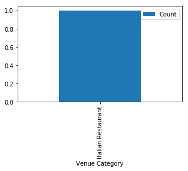

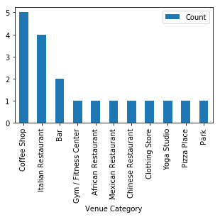

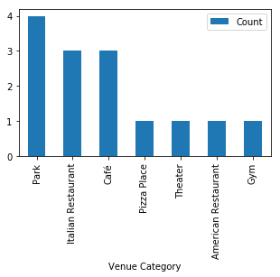

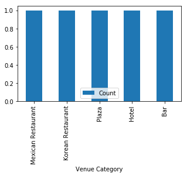

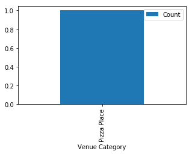

```python
df.groupby('ClusterId').plot(kind = 'bar', x = 'Venue Category', y = 'Count', figsize=(5, 3))
```

## Explore Recommended Cluster

```python
mf = manhattan_merged[manhattan_merged['Cluster Labels'] == 2]
```

```python
# create map
map_clusters = folium.Map(location=[latitude, longitude], zoom_start=11)

# set color scheme for the clusters
x = np.arange(kclusters)
ys = [i+x+(i*x)**2 for i in range(kclusters)]
colors_array = cm.rainbow(np.linspace(0, 1, len(ys)))
rainbow = [colors.rgb2hex(i) for i in colors_array]

# add markers to the map
markers_colors = []
for lat, lon, poi, cluster in zip(mf['Latitude'], mf['Longitude'], mf['Neighborhood'], mf['Cluster Labels']):
    label = folium.Popup(str(poi) + ' Cluster ' + str(cluster), parse_html=True)
    folium.CircleMarker(
        [lat, lon],
        radius=5,
        popup=label,
        color=rainbow[cluster-1],
        fill=True,
        fill_color=rainbow[cluster-1],
        fill_opacity=0.7).add_to(map_clusters)

map_clusters
```

[interactive chart not shown]

```python
manhattan_merged[manhattan_merged['Cluster Labels'] == 2]
```

|  | Borough | Neighborhood | Latitude | Longitude | Cluster Labels | 1st Most Common Venue | 2nd Most Common Venue | 3rd Most Common Venue | 4th Most Common Venue | 5th Most Common Venue | 6th Most Common Venue | 7th Most Common Venue | 8th Most Common Venue | 9th Most Common Venue | 10th Most Common Venue |
| --- | --- | --- | --- | --- | --- | --- | --- | --- | --- | --- | --- | --- | --- | --- | --- |
| 0 | Manhattan | Marble Hill | 40.876551 | -73.910660 | 2 | Gym | American Restaurant | Sandwich Place | Coffee Shop | Yoga Studio | Deli / Bodega | Supplement Shop | Steakhouse | Shopping Mall | Seafood Restaurant |
| 2 | Manhattan | Washington Heights | 40.851903 | -73.936900 | 2 | Café | Bakery | Grocery Store | Mobile Phone Shop | Supplement Shop | Sandwich Place | Mexican Restaurant | Coffee Shop | Liquor Store | Spanish Restaurant |
| 8 | Manhattan | Upper East Side | 40.775639 | -73.960508 | 2 | Italian Restaurant | Exhibit | Art Gallery | Bakery | Coffee Shop | Gym / Fitness Center | Juice Bar | Hotel | French Restaurant | Pizza Place |
| 9 | Manhattan | Yorkville | 40.775930 | -73.947118 | 2 | Italian Restaurant | Coffee Shop | Gym | Bar | Deli / Bodega | Pizza Place | Sushi Restaurant | Japanese Restaurant | Mexican Restaurant | Diner |
| 11 | Manhattan | Roosevelt Island | 40.762160 | -73.949168 | 2 | Park | Coffee Shop | Deli / Bodega | Sandwich Place | Scenic Lookout | Gym | Dry Cleaner | Baseball Field | Liquor Store | Outdoors & Recreation |
| 14 | Manhattan | Clinton | 40.759101 | -73.996119 | 2 | Theater | Italian Restaurant | Gym / Fitness Center | American Restaurant | Coffee Shop | Spa | Sandwich Place | Hotel | Wine Shop | Cocktail Bar |
| 20 | Manhattan | Lower East Side | 40.717807 | -73.980890 | 2 | Café | Coffee Shop | Pizza Place | Art Gallery | Cocktail Bar | Japanese Restaurant | Bakery | Ramen Restaurant | Chinese Restaurant | Nightclub |
| 21 | Manhattan | Tribeca | 40.721522 | -74.010683 | 2 | Park | Italian Restaurant | American Restaurant | Café | Spa | Boutique | Wine Bar | Wine Shop | Coffee Shop | Greek Restaurant |
| 22 | Manhattan | Little Italy | 40.719324 | -73.997305 | 2 | Café | Bakery | Bubble Tea Shop | Sandwich Place | Salon / Barbershop | Mediterranean Restaurant | Italian Restaurant | Cocktail Bar | Yoga Studio | Women's Store |
| 25 | Manhattan | Manhattan Valley | 40.797307 | -73.964286 | 2 | Pizza Place | Indian Restaurant | Bar | Yoga Studio | Thai Restaurant | Playground | Coffee Shop | Mexican Restaurant | Deli / Bodega | Vietnamese Restaurant |
| 26 | Manhattan | Morningside Heights | 40.808000 | -73.963896 | 2 | Park | Bookstore | American Restaurant | Coffee Shop | Burger Joint | Sandwich Place | Deli / Bodega | Pub | Café | Seafood Restaurant |
| 28 | Manhattan | Battery Park City | 40.711932 | -74.016869 | 2 | Park | Coffee Shop | Hotel | Wine Shop | Gym | Shopping Mall | Women's Store | Memorial Site | Food Court | Men's Store |
| 31 | Manhattan | Noho | 40.723259 | -73.988434 | 2 | Italian Restaurant | French Restaurant | Hotel | Cocktail Bar | Rock Club | Art Gallery | Sushi Restaurant | Grocery Store | Gift Shop | Pizza Place |
| 39 | Manhattan | Hudson Yards | 40.756658 | -74.000111 | 2 | American Restaurant | Italian Restaurant | Coffee Shop | Hotel | Gym / Fitness Center | Café | Thai Restaurant | Burger Joint | Dog Run | Restaurant |

## Compare top 10 venues of recommended neighborhood with that of originating neighborhood

```python
manhattan_merged[manhattan_merged['Neighborhood'] == 'Battery Park City']
```

|  | Borough | Neighborhood | Latitude | Longitude | Cluster Labels | 1st Most Common Venue | 2nd Most Common Venue | 3rd Most Common Venue | 4th Most Common Venue | 5th Most Common Venue | 6th Most Common Venue | 7th Most Common Venue | 8th Most Common Venue | 9th Most Common Venue | 10th Most Common Venue |
| --- | --- | --- | --- | --- | --- | --- | --- | --- | --- | --- | --- | --- | --- | --- | --- |
| 28 | Manhattan | Battery Park City | 40.711932 | -74.016869 | 2 | Park | Coffee Shop | Hotel | Wine Shop | Gym | Shopping Mall | Women's Store | Memorial Site | Food Court | Men's Store |

```python
m1[m1['PostalCode'] == 'M6E']
```

|  | PostalCode | Borough | Neighborhood | Latitude | Longitude | Yoga Studio | Accessories Store | Afghan Restaurant | Airport | Airport Food Court | Airport Gate | Airport Lounge | Airport Service | Airport Terminal | American Restaurant | Antique Shop | Aquarium | Art Gallery | Arts & Crafts Store | Asian Restaurant | Athletics & Sports | Auto Workshop | BBQ Joint | Baby Store | Bagel Shop | Bakery | Bank | Bar | Baseball Field | … |
| --- | --- | --- | --- | --- | --- | --- | --- | --- | --- | --- | --- | --- | --- | --- | --- | --- | --- | --- | --- | --- | --- | --- | --- | --- | --- | --- | --- | --- | --- | --- |
| 72 | M6E | York | Caledonia-Fairbanks, | 43.689026 | -79.453512 | 0.0 | 0.0 | 0.0 | 0.0 | 0.0 | 0.0 | 0.0 | 0.0 | 0.0 | 0.0 | 0.0 | 0.0 | 0.0 | 0.0 | 0.0 | 0.0 | 0.0 | 0.0 | 0.0 | 0.0 | 0.0 | 0.0 | 0.0 | 0.0 | … |